# Procesamiento de información - Estudio de la mujer 2026

Tiempo, género y trabajo en el Servicio Civil Peruano

**Autora:** Gianella Grijalva

**Apoyo programático:** Mariano Díaz

**Institución:** Autoridad Nacional del Servicio Civil – SERVIR

**Año:** 2026

## Objetivo del script

**Replicabilidad del procesamiento para el capítulo IV del Estudio**

Este script descarga, procesa y construye bases maestras a partir de los módulos de la Encuesta Nacional de Uso del Tiempo (ENUT 2024) del INEI.

El procesamiento incluye:

1. Descarga automática de módulos
2. Importación desde archivos ZIP
3. Limpieza de nombres de variables
4. Creación de identificadores de hogar y persona
5. Construcción de bases maestras para análisis
6. Limpieza del entorno
7. Construcción de bases de análisis del uso del tiempo
8. Generación de la base complilada para el análisis conjunto
9. Elaboración de cuadros y gráficos

Este script permite replicar completamente el procesamiento de datos utilizado en el capítulo: “Tiempo, género y trabajo en el Servicio Civil Peruano”. del Estudio: La Mujer en el Servicio Civil Peruano, 2026

Fuente: https://www.gob.pe/institucion/servir/informes-publicaciones/7823960-la-mujer-en-el-servicio-civil-peruano-2026

## 0. Carga de Librerías (Load libraries)

**Instalación de librerías**

```r
library(rvest)
library(stringr)
library(readr)
library(purrr)
library(dplyr)
library(tidyr)
library(kableExtra)
library(survey)
library(ggplot2)
library(patchwork)
```

## 1. Descarga automática de las Bases de Datos ENUT (Download ENUT data)

**Creación automatizada de enlaces de descarga**

Las bases de datos de INEI no se pueden web scrappear, en cambio tienen patrones en los enlaces de descarga.

```r
modulos <- c("1849","1850", "1851", "1852", "1853", "1854", "1855")
codigo_encuesta <- "963"

links_zip <- paste0(
  "https://proyectos.inei.gob.pe/iinei/srienaho/descarga/CSV/",
  codigo_encuesta,
  "-Modulo",
  modulos,
  ".zip"
)
```

## 2. Importación de los módulos zip de la ENUT (Import modules)

**2.1. Importar las bases de datos de los módulos ZIP**

Se importó las bases de datos directamente, sin la necesidad de descargar las carpetas zip. El código crea archivoz zip temporales, los extrae e importa la base de datos.

```r
leer_csv_desde_zip <- function(url) {
  zip_tmp <- tempfile(fileext = ".zip")
  ok <- try(
    download.file(url, zip_tmp, mode = "wb", quiet = TRUE),
    silent = TRUE
  )
  if (inherits(ok, "try-error")) {
    message("✗ No existe: ", basename(url))
    return(NULL)
  }
  contenido <- unzip(zip_tmp, list = TRUE)
  csv_name <- contenido$Name[str_detect(contenido$Name, "\\.csv$")][1]
  if (is.na(csv_name)) return(NULL)
  csv_tmp <- unzip(zip_tmp, files = csv_name, exdir = tempdir())
  read_csv(csv_tmp, show_col_types = FALSE)
}

bases_inei <- map(links_zip, leer_csv_desde_zip)
```

**2.2. Convertir lista de bases de datos**

Asigna nombres a cada base de datos importada para facilitar su identificación.

```r
# Asignar nombres a cada base dentro de la lista
names(bases_inei) <- paste0("enut_2024_", seq_along(bases_inei))

# Visualizar los nombres de las bases importadas
names(bases_inei)
```

```
## [1] "enut_2024_1" "enut_2024_2" "enut_2024_3" "enut_2024_4" "enut_2024_5"
## [6] "enut_2024_6" "enut_2024_7"
```

## 3. Limpieza de nombres de variables de la Base de datos (Data cleaning)

**3.1. Limpieza de las bases de datos originales**

Limpiamos los nombres de las bases de datos

```r
bases_inei <- purrr::map(bases_inei, ~ dplyr::rename_with(.x, tolower))
```

```r
# Crear objetos individuales para facilitar el trabajo posterior
names(bases_inei) <- paste0("enut_2024_", seq_along(bases_inei))

list2env(bases_inei, envir = .GlobalEnv)
```

```
## <environment: R_GlobalEnv>
```

## 4. Creación de identificadores (Create household and individual IDs)

**4.1. Creación de identificadores (hogares y personas)**

1. Función para crear ID de HOGAR (Aplica a TODOS los módulos)
2. Función para crear ID de PERSONA (Aplica SOLO a módulos individuales)

```r
crear_id_hogar <- function(df) {
  df %>%
    mutate(
      id_hogar = paste(cong, nselv, hogar, sep = "_")
    )
}

crear_id_persona <- function(df) {
  df %>%
    mutate(
      id_persona = paste(cong, nselv, hogar, p201, sep = "_")
    )
}
```

**4.2. Aplicar identificadores a los respectivos módulos**

1. Módulos hogar

```r
enut_2024_1 <- enut_2024_1 %>%
  crear_id_hogar()
```

2. Módulos personas

```r
enut_2024_2 <- enut_2024_2 %>%
  crear_id_hogar() %>%
  crear_id_persona()

enut_2024_6 <- enut_2024_6 %>%
  crear_id_hogar() %>%
  crear_id_persona()

enut_2024_7 <- enut_2024_7 %>%
  crear_id_hogar() %>%
  crear_id_persona()
```

## 5. Construcción de Bases de Datos Maestras (Build master datasets)

**5.1. Contrucción de Base Maestra de Hogares**

```r
base_hogares <- enut_2024_1 %>%
  select(
    id_hogar,
    cong,
    nselv,
    hogar
    # aquí luego se agregarán variables del hogar
  ) %>%
  distinct()

head(base_hogares)
```

| id_hogar | cong | nselv | hogar |
| --- | --- | --- | --- |
| 0000301_0003_1 | 0000301 | 0003 | 1 |
| 0000301_0013_1 | 0000301 | 0013 | 1 |
| 0000301_0033_1 | 0000301 | 0033 | 1 |
| 0000301_0053_1 | 0000301 | 0053 | 1 |
| 0000301_0062_1 | 0000301 | 0062 | 1 |
| 0000301_0072_1 | 0000301 | 0072 | 1 |

**5.2. Construcción de Base Maestra de Personas**

1. Tomamos de base el módulo 200: características demográficas
2. Luego anexamos también el módulo 100: características del hogar
3. Finalmente, también anexamos el módulo 700: variables de empleo

```r
base_personas <- enut_2024_2 %>%
  select(
    id_persona,
    id_hogar,
    cong,
    nselv,
    hogar,
    p201,       # código de persona
    p203,       # relación jefe de hogar
    p204,       # sexo
    p205_a,     # edad en años
    p206,       # miembro del hogar
    p207,       # ausente en el hogar
    p208,       # presente en el hogar
    p213,       # nivel educativo
    p213_a,     # años de estudio
    per_resfin, # resultado de la encuesta persona
    resfin,     # resultado final hogar
    resfin_v    # resultado final vivienda
    # aquí luego se agregarán otras variables, etc.
  ) %>%
  distinct()

  # Variables del módulo de hogar
  base_personas <- base_personas %>%
    left_join(
      enut_2024_1 %>%
        select(
          id_hogar,
          # Variables base hogar
          area,   # urbana o rural
          ubigeo  # codigo inei
        ),
      by = "id_hogar"
    )

  # Variables del módulo de empleo
  base_personas <- base_personas %>%
    left_join(
      enut_2024_7 %>%
        select(
          id_persona,
          p703,
          p704,
          p705,
          # Variables base de empleo
          p710,        # categoría ocupacional (asalariado)
          p711,        # sector de empleo
          p717,        # tamaño de entidad
          p708_pod,    # código ocupacional
          p766         # nivel educativo de empleo
        ),
      by = "id_persona"
    )

  # Variables del módulo de tiempo
  base_personas <- base_personas %>%
    left_join(
      enut_2024_6 %>%
        select(
          id_persona,
          # Variable estado civil
          estado_civil
          ) %>%
        distinct(),
      by = "id_persona"
    )

head(base_personas)
```

| id_persona | id_hogar | cong | nselv | hogar | p201 | p203 | p204 | p205_a | p206 | p207 | p208 | p213 | p213_a | per_resfin | resfin | resfin_v | area | ubigeo | p703 | p704 | p705 | p710 | p711 | p717 | p708_pod | p766 | estado_civil |
| --- | --- | --- | --- | --- | --- | --- | --- | --- | --- | --- | --- | --- | --- | --- | --- | --- | --- | --- | --- | --- | --- | --- | --- | --- | --- | --- | --- |
| 0000301_0003_1_1 | 0000301_0003_1 | 0000301 | 0003 | 1 | 1 | 1 | 2 | 37 | 1 | 2 | NA | 8 | NA | 1 | 1 | 1 | 1 | 240201 | 1 | NA | NA | 2 | NA | 1 | 5212 | 6 | 6 |
| 0000301_0003_1_2 | 0000301_0003_1 | 0000301 | 0003 | 1 | 2 | 3 | 2 | 20 | 1 | 1 | NA | NA | NA | NA | 1 | 1 | 1 | 240201 | NA | NA | NA | NA | NA | NA | NA | NA | NA |
| 0000301_0003_1_3 | 0000301_0003_1 | 0000301 | 0003 | 1 | 3 | 3 | 2 | 14 | 1 | 1 | NA | NA | NA | NA | 1 | 1 | 1 | 240201 | NA | NA | NA | NA | NA | NA | NA | NA | NA |
| 0000301_0003_1_4 | 0000301_0003_1 | 0000301 | 0003 | 1 | 4 | 3 | 1 | 12 | 1 | 2 | NA | 3 | 1 | 1 | 1 | 1 | 1 | 240201 | 2 | 2 | 2 | NA | NA | NA | NA | 4 | 6 |
| 0000301_0003_1_5 | 0000301_0003_1 | 0000301 | 0003 | 1 | 5 | 3 | 2 | 8 | 1 | 2 | NA | 2 | NA | NA | 1 | 1 | 1 | 240201 | NA | NA | NA | NA | NA | NA | NA | NA | NA |
| 0000301_0013_1_1 | 0000301_0013_1 | 0000301 | 0013 | 1 | 1 | 1 | 1 | 49 | 1 | 2 | NA | 8 | NA | 1 | 1 | 1 | 1 | 240201 | 1 | NA | NA | 2 | NA | 1 | 6222 | 6 | 5 |

**Notas metodológicas:**

1. Las variables de área de residencia y ubigeo se incorporan desde el módulo de hogar (100), utilizando como llave el identificador del hogar. Estas variables se consideran atributos del hogar compartidos por todos sus miembros.
2. Se seleccionan únicamente las variables necesarias para la construcción de indicadores de empleo, con el fin de mantener el script liviano y trazable. Estas variables de empleo se incorporan a la base de personas mediante un cruce m:1 usando el identificador individual.

**5.3. Recodificación y asignación de etiquetas de variables (base_personas)**

Recodificamos las variables originales, y en algunos casos se crean nuevas variables de caracterización

Variables sociodemográficas

```r
base_personas <- base_personas %>%
  mutate(

# -------------------------------------------------
# VARIABLES SOCIODEMOGRÁFICAS
# -------------------------------------------------

    # Relación con jefe de hogar
    p203 = factor(
      p203,
      levels = 1:13,
      labels = c(
        "Jefa/Jefe",
        "Esposo(a)",
        "Hija(o) / Hijastra(o)",
        "Nuera/Yerno",
        "Nieta(o)",
        "Madre/Padre",
        "Suegra/Suegro",
        "Hermana(o)",
        "Cuñada(o)",
        "Otra(o) pariente",
        "Trabajadora(or) del Hogar",
        "Pensionista",
        "Otra(o) no pariente"
      )
    ),

    # Sexo
    sexo = factor(
      p204,
      levels = c(1,2),
      labels = c("Hombre","Mujer")
    ),

    # Miembros del hogar
    p206 = factor(p206, levels = c(1,2), labels = c("Sí","No")),
    p207 = factor(p207, levels = c(1,2), labels = c("Sí","No")),
    p208 = factor(p208, levels = c(1,2), labels = c("Sí","No")),

    # Edad
    rango_edad = case_when(
      p205_a <= 12 ~ 1,
      p205_a <= 17 ~ 2,
      p205_a <= 29 ~ 3,
      p205_a <= 39 ~ 4,
      p205_a <= 49 ~ 5,
      p205_a <= 59 ~ 6,
      p205_a >= 60 ~ 7
    ),

    rango_edad = factor(
      rango_edad,
      levels = 1:7,
      labels = c(
        "Hasta 12 años",
        "13 a 17 años",
        "18 a 29 años",
        "30 a 39 años",
        "40 a 49 años",
        "50 a 59 años",
        "60 años a más"
      )
    ),

    # Nivel educativo
    niv_edu = case_when(
      p766 %in% c(1,2) ~ 1,
      p766 %in% c(3,4,7) ~ 2,
      p766 %in% c(5,6) ~ 3,
      p766 %in% c(8,9) ~ 4,
      p766 %in% c(10,11,12) ~ 5
    ),

    niv_edu = factor(
      niv_edu,
      levels = 1:5,
      labels = c(
        "Sin nivel / Inicial",
        "Primaria y Ed. Básica",
        "Secundaria",
        "Superior no universitaria",
        "Universitaria y Postgrado"
      )
    ),

    # Estado civil
    estado_civil = factor(
      estado_civil,
      levels = 1:6,
      labels = c(
        "Conviviente",
        "Casado/a",
        "Viudo/a",
        "Divorciado/a",
        "Separado/a",
        "Soltero/a"
      )
    ),

    ecivil = case_when(
      estado_civil %in% c("Conviviente","Casado/a") ~ "Con pareja",
      estado_civil %in% c("Viudo/a","Divorciado/a","Separado/a","Soltero/a") ~ "Sin pareja"
    ),

    ecivil = factor(ecivil)
  )
```

Variables de empleo

```r
base_personas <- base_personas %>%
  mutate(

# -------------------------------------------------
# VARIABLES DE EMPLEO
# -------------------------------------------------

    # Categoría ocupacional
    p710 = factor(
      p710,
      levels = 1:10,
      labels = c(
        "Empleador o patrono",
        "Trabajador independiente",
        "Empleado u obrero",
        "Ayudante en negocio familiar",
        "Ayudante en empleo de familiar",
        "Trabajador del hogar",
        "Aprendiz / practicante remunerado",
        "Practicante sin remuneración",
        "Ayudante negocio familiar otro hogar",
        "Ayudante empleo familiar otro hogar"
      )
    ),

    # Sector institucional (desde la p711, solo para asalariados)
    sector_inst = factor(
      p711,
      levels = 1:6,
      labels = c(
        "Fuerzas Armadas / Policía Nacional del Perú",
        "Administración pública",
        "Empresa pública",
        "Empresas especiales de servicios (SERVICE)",
        "Empresa o patrono privado",
        "Otra"
      )
    ),

    sector = case_when(
      p711 == 1 ~ 1,              # FFAA / PNP
      p711 %in% c(2,3) ~ 2,       # Sector público
      p711 %in% c(4,5,6) ~ 3,     # Sector privado
      TRUE ~ NA_real_
    ),

    sector = factor(
      sector,
      levels = c(1,2,3),
      labels = c(
        "FFAA / Policía",
        "Sector público",
        "Sector privado"
      )
    ),

    # GRUPO OCUPACIONAL

    # Código ocupacional a nivel de cuatro dígitos (desde la p708_pod)
    p708_pod_str = stringr::str_pad(
      as.character(p708_pod),
      width = 4,
      side = "left",
      pad = "0"
    ),

    # Código ocupacional a nivel de dos dígitos
    gocupa_2d = as.numeric(substr(p708_pod_str, 1, 2)),

    # Código ocupacional a nivel de un dígito
    gr_grupo_ocu = case_when(
      gocupa_2d %in% c(11,13) ~ 1,
      gocupa_2d %in% c(26,41,21,24,25) ~ 2,
      gocupa_2d %in% c(33,31,42,35,34,43) ~ 3,
      gocupa_2d == 44 ~ 4,
      gocupa_2d %in% c(96,93,83,71,72,92) ~ 5,
      gocupa_2d %in% c(54,53,91,51,74,73,81) ~ 6,
      gocupa_2d %in% c(23,22,32) ~ 7,
      TRUE ~ NA_real_
    ),

    gr_grupo_ocu = factor(
      gr_grupo_ocu,
      levels = 1:7,
      labels = c(
        "Funcionarios y directivos",
        "Profesionales",
        "Técnicos",
        "Auxiliares",
        "Prestadores de servicios indirectos",
        "Prestadores de servicios directos",
        "Carreras especiales"
      )
    ),
)
```

Complementamos el directorio de las categorías ocupacionales

```r
dic_gocupa_2d <- tibble::tribble(
  ~gocupa_2d, ~gocupa_2d_cat,

  11, "Miembros del Poder Ejecutivo, Legislativo, Judicial y Directores Generales",
  12, "Directores y gerentes en servicios financieros, administrativos y comerciales",
  13, "Directores y gerentes de producción, tecnología y transporte",
  14, "Gerentes de hoteles, restaurantes, comercios, abastecimiento, distribución y otros servicios",

  21, "Profesionales de las ciencias y de la ingeniería",
  22, "Profesionales de la salud",
  23, "Profesionales de la enseñanza",
  24, "Especialistas en organización de la administración pública y de empresas",
  25, "Profesionales de tecnología de la información y las comunicaciones",
  26, "Profesionales en derecho, en ciencias sociales y culturales",

  31, "Profesionales técnicos de las ciencias y la ingeniería",
  32, "Profesionales técnicos de la salud",
  33, "Profesionales técnicos en operaciones financieras, estadísticas y administrativas",
  34, "Profesionales técnicos de servicios jurídicos, sociales, culturales y afines",
  35, "Técnicos en tecnología de la información y las comunicaciones",

  41, "Jefes de áreas administrativas y oficinistas",
  42, "Empleados en trato directo con el público",
  43, "Empleados contables y encargados del registro de materiales",
  44, "Otro personal de apoyo administrativo",

  51, "Trabajadores de los servicios personales",
  52, "Vendedores",
  53, "Trabajadores de cuidados personales",
  54, "Personal de servicios de protección",

  61, "Agricultores y trabajadores calificados de explotaciones agropecuarias con destino al mercado",
  62, "Trabajadores forestales calificados, pescadores y cazadores",
  63, "Trabajadores agropecuarios, pescadores, cazadores y recolectores de subsistencia",

  71, "Trabajadores de la construcción, edificación y acabados excluyendo electricistas",
  72, "Trabajadores de la metalurgia, la construcción metálica y afines",
  73, "Artesanos y trabajadores en la elaboración de productos de madera, papel, textiles, cuero y piel",
  74, "Trabajadores especializados en electricidad, equipos electrónicos, telecomunicaciones e instrumentos",
  75, "Trabajadores en el procesamiento y elaboración de alimentos, bebidas y productos de tabaco",

  81, "Operadores de instalaciones fijas y maquinaria industrial",
  82, "Ensambladores",
  83, "Conductores de vehículos y operadores de maquinaria móvil pesada",

  91, "Limpiadores y asistentes domésticos",
  92, "Peones agropecuarios, pesqueros y forestales",
  93, "Peones de la minería, la construcción, la industria manufacturera y el transporte",
  94, "Cocineros y ayudantes de preparación de alimentos",
  95, "Vendedores ambulantes",
  96, "Recolectores de desechos y otras ocupaciones elementales",

  1, "Oficiales de las Fuerzas Armadas y Fuerzas Policiales",
  2, "Suboficiales de las Fuerzas Armadas y Fuerzas Policiales",
  3, "Otros miembros de las Fuerzas Armadas y Fuerzas Policiales"
)

base_personas <- base_personas %>%
  left_join(
    dic_gocupa_2d,
    by = "gocupa_2d"
  )

base_personas <- base_personas %>%
  mutate(
    gocupa_2d_cat = factor(
      gocupa_2d_cat,
      levels = dic_gocupa_2d$gocupa_2d_cat
    )
  )
```

**Nota metodológica:** Solo se ha categorizado el grupo ocupacional que pertenece al sector público, por ello existe el desglose de prestadores de servicios directos e indirectos.

**OBJETOS FINALES DISPONIBLES**

- base_hogares → una fila por hogar
- base_personas → una fila por persona

A partir de aquí:

- base_hogares se alimenta SOLO con variables de nivel hogar
- base_personas se alimenta SOLO con variables individuales

Los cruces futuros SIEMPRE serán:

- left_join(base_hogares, …, by = “id_hogar”)
- left_join(base_personas, …, by = “id_persona”)

## 6. Limpieza del entorno (Environmental cleaning)

```r
# -------------------------------------------------
# Conserva solo las bases principales
# -------------------------------------------------

objetos_conservar <- c(
  "base_hogares",
  "base_personas",
  paste0("enut_2024_", 1:7)
)

rm(list = setdiff(ls(), objetos_conservar))
```

## 7. Procesamiento y contrucción de la base de datos de uso del tiempo (Build time dataset)

**7.1 Preparación de la base de datos del uso del tiempo**

**A) Selección de la actividad principal para el análisis**

1. Merging and filter

Se realizó un merge sobre la BD con módulo 600, agregando variables de las BD con módulo 200 para quedarnos solo con resultado completo

```r
base_uso_tiempo <- enut_2024_6 %>%
  left_join(
    enut_2024_2 %>%
      select(
        id_persona,
        per_resfin   # resultado final de la encuesta
      ),
    by = "id_persona"
  )

base_uso_tiempo <- base_uso_tiempo %>%
  filter(per_resfin == 1)
```

2. Mantenemos solo la primera actividad (actividad principal)

Mantener las variables de la actividad 1, eliminamos actividades 2 y 3

```r
base_uso_tiempo <- base_uso_tiempo %>%
  select(
    -p600_dsem_act2, -p600_dsem_act3,
    -p600_sab_act2,  -p600_sab_act3,
    -p600_dom_act2,  -p600_dom_act3,
    -obs_cap600, -resfin_o
  )
```

3. Renombramos las variables de la act1 como la actividad general

```r
base_uso_tiempo <- base_uso_tiempo %>%  #renombramos Actividad 1
  rename(
    p600_dsem = p600_dsem_act1,
    p600_sab  = p600_sab_act1,
    p600_dom  = p600_dom_act1
  )

base_uso_tiempo <- base_uso_tiempo %>%  #Crea ID temporal
  mutate(id_temp = row_number())


base_uso_tiempo <- base_uso_tiempo %>%  #Ancho a largo
  pivot_longer(
    cols = starts_with("p600_"),
    names_to  = "dia",
    values_to = "actividad"
  )

base_uso_tiempo <- base_uso_tiempo %>%  #Elimina ID temporal
  select(-id_temp)

base_uso_tiempo <- base_uso_tiempo %>%  #Generar tipo-dia
  mutate(
    tipo_dia = case_when(
      dia == "p600_dsem" ~ 1,
      dia == "p600_sab"  ~ 2,
      dia == "p600_dom"  ~ 3
    )
  )

base_uso_tiempo <- base_uso_tiempo %>%  #Recodifica tipo_dia2 (día semana / fin de semana)
  mutate(
    tipo_dia2 = case_when(
      tipo_dia == 1 ~ 1,   # día de semana
      tipo_dia %in% c(2, 3) ~ 2
    )
  )

base_uso_tiempo <- base_uso_tiempo %>%  #Eliminar variable dia
  select(-dia)
```

**B) Construcción de las variables agregadas de las actividades (de 4 dígitos a 2 dígitos)**

1. Construcción de sección de actividad (2 primeros dígitos)

Regla: - Si el código tiene 2 dígitos → se usa completo - Si tiene 3 o 4 dígitos → se extraen los 2 primeros

```r
base_uso_tiempo <- base_uso_tiempo %>%
  mutate(
    actividad_str = as.character(actividad),

    division = case_when(
      nchar(actividad_str) == 2 ~ as.numeric(actividad_str),
      nchar(actividad_str) >= 3 ~ as.numeric(substr(actividad_str, 1, 2)),
      TRUE ~ NA_real_
    )
  )

base_uso_tiempo <- base_uso_tiempo %>%
  select(-actividad_str)
```

2. Grandes divisiones (agregación a un dígito)

```r
base_uso_tiempo <- base_uso_tiempo %>%
  mutate(
    g_division = case_when(
      division %in% c(11,12,13,14,10) ~ 1,  # Trabajo ocupación
      division %in% c(21,22,23)       ~ 2,  # Autoconsumo
      division %in% c(31:37)          ~ 3,  # Trabajo doméstico
      division %in% c(41:44)          ~ 4,  # Cuidados no remunerados
      division %in% c(51:53)          ~ 5,  # Trabajo no remunerado externo
      division %in% c(61,62)          ~ 6,  # Estudio
      division %in% c(71:74)          ~ 7,  # Convivencia / recreación
      division %in% c(81:84)          ~ 8,  # Medios
      division %in% c(91,92,99)       ~ 9,  # Cuidado personal
      TRUE ~ NA_real_
    )
  )
```

3. Agrupación de actividades por secciones

```r
base_uso_tiempo <- base_uso_tiempo %>%
  mutate(
    seccion = case_when(
      g_division %in% c(1, 2)        ~ 1,  # Trabajo (ocupación + autoconsumo)
      g_division %in% c(3, 4, 5)     ~ 2,  # Trabajo no remunerado
      g_division %in% c(6, 7, 8, 9)  ~ 3,  # Actividades personales
      TRUE ~ NA_real_
    )
  )
```

**C) Construcción de variables para el cálculo del tiempo destinado a cada actividad**

1. Extracción de la hora de inicio y fin destinado a cada actividad

```r
base_uso_tiempo <- base_uso_tiempo %>%
  mutate(
    # extraemos horas como texto
    hora_ini_str = substr(hora_id, 1, 5),
    hora_fin_str = substr(hora_id, 9, 13),

    # indicador de cruce de medianoche o uso de 24:xx
    cruza_medianoche = str_detect(hora_id, "24:") |
      hora_fin_str < hora_ini_str
  )
```

2. Convertimos SOLO horas válidas (excluyendo 24:xx)

```r
base_uso_tiempo <- base_uso_tiempo %>%
  mutate(
    hora_ini_min = if_else(
      hora_ini_str == "24:00",
      0,
      as.numeric(lubridate::hm(hora_ini_str))
    ),

    hora_fin_min = if_else(
      str_detect(hora_fin_str, "24:"),
      NA_real_,
      as.numeric(lubridate::hm(hora_fin_str))
    )
  )
```

3. Cálculo de tiempo por cada actividad (10 min en 10 min)

```r
base_uso_tiempo <- base_uso_tiempo %>%
  mutate(
    tiempo_seg = case_when(
      cruza_medianoche == TRUE ~ 600,  # regla INEI
      TRUE ~ hora_fin_min - hora_ini_min
    )
  )
```

4. Se eliminan variables intermedias

```r
base_uso_tiempo <- base_uso_tiempo %>%
  select(
    -hora_ini_str, -hora_fin_str,
    -hora_ini_min, -hora_fin_min,
    -cruza_medianoche
  )
```

5. Conversión a minutos

```r
base_uso_tiempo <- base_uso_tiempo %>%
  mutate(
    tiempo_min = tiempo_seg / 60
  )
```

```r
head(base_uso_tiempo)
```

| id | cong | nselv | hogar | p201 | tot_hogar | ccdd | nombredd | ccpp | nombrepp | ccdi | nombredi | cccp | nombrecp | ubigeo | zona | mza | aer_ini | aer_fin | long | lat | area | reg_nat | vivienda | hora_id | estado_civil | resfin | resfin_v | factorfinal | id_hogar | … |
| --- | --- | --- | --- | --- | --- | --- | --- | --- | --- | --- | --- | --- | --- | --- | --- | --- | --- | --- | --- | --- | --- | --- | --- | --- | --- | --- | --- | --- | --- | --- |
| 79094 | 0000301 | 0003 | 1 | 1 | 1 | 24 | TUMBES | 02 | CONTRALMIRANTE VILLAR | 01 | ZORRITOS | 0001 | ZORRITOS | 240201 | 00100 | 055 | 000 | 000 | -80.67557 | -3.681834 | 1 | 1 | 001 | 01:00 - 01:10 | 6 | 1 | 1 | 1989.954 | 0000301_0003_1 | … |
| 79094 | 0000301 | 0003 | 1 | 1 | 1 | 24 | TUMBES | 02 | CONTRALMIRANTE VILLAR | 01 | ZORRITOS | 0001 | ZORRITOS | 240201 | 00100 | 055 | 000 | 000 | -80.67557 | -3.681834 | 1 | 1 | 001 | 01:00 - 01:10 | 6 | 1 | 1 | 1989.954 | 0000301_0003_1 | … |
| 79094 | 0000301 | 0003 | 1 | 1 | 1 | 24 | TUMBES | 02 | CONTRALMIRANTE VILLAR | 01 | ZORRITOS | 0001 | ZORRITOS | 240201 | 00100 | 055 | 000 | 000 | -80.67557 | -3.681834 | 1 | 1 | 001 | 01:00 - 01:10 | 6 | 1 | 1 | 1989.954 | 0000301_0003_1 | … |
| 79094 | 0000301 | 0003 | 1 | 1 | 1 | 24 | TUMBES | 02 | CONTRALMIRANTE VILLAR | 01 | ZORRITOS | 0001 | ZORRITOS | 240201 | 00100 | 055 | 000 | 000 | -80.67557 | -3.681834 | 1 | 1 | 001 | 01:10 - 01:20 | 6 | 1 | 1 | 1989.954 | 0000301_0003_1 | … |
| 79094 | 0000301 | 0003 | 1 | 1 | 1 | 24 | TUMBES | 02 | CONTRALMIRANTE VILLAR | 01 | ZORRITOS | 0001 | ZORRITOS | 240201 | 00100 | 055 | 000 | 000 | -80.67557 | -3.681834 | 1 | 1 | 001 | 01:10 - 01:20 | 6 | 1 | 1 | 1989.954 | 0000301_0003_1 | … |
| 79094 | 0000301 | 0003 | 1 | 1 | 1 | 24 | TUMBES | 02 | CONTRALMIRANTE VILLAR | 01 | ZORRITOS | 0001 | ZORRITOS | 240201 | 00100 | 055 | 000 | 000 | -80.67557 | -3.681834 | 1 | 1 | 001 | 01:10 - 01:20 | 6 | 1 | 1 | 1989.954 | 0000301_0003_1 | … |

**7.2 Cálculo del tiempo destinado a actividades**

**7.2.1. Agregación a nivel de secciones (tr_ocup, tr_no-rem, act_pers)**

1. Agregación a nivel de sección

Sumamos el tiempo por persona, tipo de día y sección

```r
tiempo_ind_seccion_long <- base_uso_tiempo %>%
  filter(!is.na(seccion), !is.na(tipo_dia)) %>% # Nos quedamos solo con registros bien clasificados
  group_by(
    id_persona,
    factorfinal,
    tipo_dia,    # 1 = día de semana, 2 = sábado y 3 = domingo
    seccion      # 1, 2, 3
  ) %>%
  summarise(
    tiempo_seg = sum(tiempo_seg, na.rm = TRUE),
    .groups = "drop"
  )

head(tiempo_ind_seccion_long)
```

| id_persona | factorfinal | tipo_dia | seccion | tiempo_seg |
| --- | --- | --- | --- | --- |
| 0000301_0003_1_1 | 1989.954 | 1 | 1 | 32400 |
| 0000301_0003_1_1 | 1989.954 | 1 | 2 | 7800 |
| 0000301_0003_1_1 | 1989.954 | 1 | 3 | 46200 |
| 0000301_0003_1_1 | 1989.954 | 2 | 1 | 27600 |
| 0000301_0003_1_1 | 1989.954 | 2 | 2 | 10800 |
| 0000301_0003_1_1 | 1989.954 | 2 | 3 | 48000 |

**Nota metodológica:** El tiempo de uso se agrega a nivel de persona. Para cada sección de actividad se construyen variables diferenciadas por tipo de día (día de semana, sábado y domingo), expresadas en segundos y en formato hh:mm para presentación.

2. Recodificar tipo de día a texto (para nombres de columnas)

```r
tiempo_persona_long <- tiempo_ind_seccion_long %>%
  mutate(
    dia_txt = case_when(
      tipo_dia == 1 ~ "dsem",
      tipo_dia == 2 ~ "sab",
      tipo_dia == 3 ~ "dom"
    )
  )
```

3. Crear nombre de variable (sección + día)

```r
tiempo_persona_long <- tiempo_persona_long %>%
  mutate(
    var_tiempo = paste0(
      "t_sec", seccion, "_", dia_txt
    )
  )
```

4. Pasar a formato wide (una fila = una persona)

```r
tiempo_persona_wide <- tiempo_persona_long %>%
  select(
    id_persona,
    factorfinal,
    var_tiempo,
    tiempo_seg
  ) %>%
  pivot_wider(
    names_from  = var_tiempo,
    values_from = tiempo_seg,
    values_fill = 0
  )
```

5. Crear variables de validación (segundos)

Totales = 86400 segundos

```r
tiempo_persona_wide <- tiempo_persona_wide %>%
  mutate(
    tot_dsem = t_sec1_dsem + t_sec2_dsem + t_sec3_dsem,
    tot_sab  = t_sec1_sab  + t_sec2_sab  + t_sec3_sab,
    tot_dom  = t_sec1_dom  + t_sec2_dom  + t_sec3_dom
  )
```

```r
head(tiempo_persona_wide)
```

| id_persona | factorfinal | t_sec1_dsem | t_sec2_dsem | t_sec3_dsem | t_sec1_sab | t_sec2_sab | t_sec3_sab | t_sec1_dom | t_sec2_dom | t_sec3_dom | tot_dsem | tot_sab | tot_dom |
| --- | --- | --- | --- | --- | --- | --- | --- | --- | --- | --- | --- | --- | --- |
| 0000301_0003_1_1 | 1989.954 | 32400 | 7800 | 46200 | 27600 | 10800 | 48000 | 33600 | 12600 | 40200 | 86400 | 86400 | 86400 |
| 0000301_0003_1_4 | 1989.954 | 0 | 0 | 86400 | 0 | 16800 | 69600 | 0 | 13800 | 72600 | 86400 | 86400 | 86400 |
| 0000301_0013_1_1 | 1989.954 | 22200 | 0 | 64200 | 23400 | 0 | 63000 | 0 | 0 | 86400 | 86400 | 86400 | 86400 |
| 0000301_0033_1_1 | 1989.954 | 0 | 14400 | 72000 | 0 | 27000 | 59400 | 2400 | 10800 | 73200 | 86400 | 86400 | 86400 |
| 0000301_0033_1_2 | 1989.954 | 26400 | 0 | 60000 | 22200 | 1800 | 62400 | 0 | 0 | 86400 | 86400 | 86400 | 86400 |
| 0000301_0033_1_3 | 1989.954 | 0 | 0 | 86400 | 0 | 20400 | 66000 | 0 | 13200 | 73200 | 86400 | 86400 | 86400 |

6. Eliminar variables de validación

```r
tiempo_persona_wide <- tiempo_persona_wide %>%
  select(
    -tot_dsem,
    -tot_sab,
    -tot_dom
  )
```

7. Merge: Uso del tiempo a Base Maestra de Personas

```r
base_personas <- base_personas %>%
  left_join(
    tiempo_persona_wide,
    by = "id_persona"
  )

head(base_personas)
```

| id_persona | id_hogar | cong | nselv | hogar | p201 | p203 | p204 | p205_a | p206 | p207 | p208 | p213 | p213_a | per_resfin | resfin | resfin_v | area | ubigeo | p703 | p704 | p705 | p710 | p711 | p717 | p708_pod | p766 | estado_civil | sexo | rango_edad | … |
| --- | --- | --- | --- | --- | --- | --- | --- | --- | --- | --- | --- | --- | --- | --- | --- | --- | --- | --- | --- | --- | --- | --- | --- | --- | --- | --- | --- | --- | --- | --- |
| 0000301_0003_1_1 | 0000301_0003_1 | 0000301 | 0003 | 1 | 1 | Jefa/Jefe | 2 | 37 | Sí | No | NA | 8 | NA | 1 | 1 | 1 | 1 | 240201 | 1 | NA | NA | Trabajador independiente | NA | 1 | 5212 | 6 | Soltero/a | Mujer | 30 a 39 años | … |
| 0000301_0003_1_2 | 0000301_0003_1 | 0000301 | 0003 | 1 | 2 | Hija(o) / Hijastra(o) | 2 | 20 | Sí | Sí | NA | NA | NA | NA | 1 | 1 | 1 | 240201 | NA | NA | NA | NA | NA | NA | NA | NA | NA | Mujer | 18 a 29 años | … |
| 0000301_0003_1_3 | 0000301_0003_1 | 0000301 | 0003 | 1 | 3 | Hija(o) / Hijastra(o) | 2 | 14 | Sí | Sí | NA | NA | NA | NA | 1 | 1 | 1 | 240201 | NA | NA | NA | NA | NA | NA | NA | NA | NA | Mujer | 13 a 17 años | … |
| 0000301_0003_1_4 | 0000301_0003_1 | 0000301 | 0003 | 1 | 4 | Hija(o) / Hijastra(o) | 1 | 12 | Sí | No | NA | 3 | 1 | 1 | 1 | 1 | 1 | 240201 | 2 | 2 | 2 | NA | NA | NA | NA | 4 | Soltero/a | Hombre | Hasta 12 años | … |
| 0000301_0003_1_5 | 0000301_0003_1 | 0000301 | 0003 | 1 | 5 | Hija(o) / Hijastra(o) | 2 | 8 | Sí | No | NA | 2 | NA | NA | 1 | 1 | 1 | 240201 | NA | NA | NA | NA | NA | NA | NA | NA | NA | Mujer | Hasta 12 años | … |
| 0000301_0013_1_1 | 0000301_0013_1 | 0000301 | 0013 | 1 | 1 | Jefa/Jefe | 1 | 49 | Sí | No | NA | 8 | NA | 1 | 1 | 1 | 1 | 240201 | 1 | NA | NA | Trabajador independiente | NA | 1 | 6222 | 6 | Separado/a | Hombre | 40 a 49 años | … |

8. Tiempo promedio en fin de semana (sabado + domingo)

```r
base_personas <- base_personas %>%
  mutate(
    t_sec1_fsem = (t_sec1_sab + t_sec1_dom) / 2, # Sección 1
    t_sec2_fsem = (t_sec2_sab + t_sec2_dom) / 2, # Sección 2
    t_sec3_fsem = (t_sec3_sab + t_sec3_dom) / 2  # Sección 3
  )
```

**Nota metodológica:** El tiempo de fin de semana se calcula como el promedio simple del tiempo reportado el sábado y el domingo, manteniendo las variables en segundos para su uso analítico.

9. Segunda limpieza del entorno

```r
objetos_conservar <- c(
  "base_hogares",
  "base_personas",
  "base_uso_tiempo"
)

rm(list = setdiff(ls(), objetos_conservar))
```

**Resultado Final**

base_personas

- 1 fila = 1 persona
- variables en columnas del tiempo por seccion para dsem, sab y dom
- tiempo en SEGUNDOS para análisis

**7.2.2. Agregación a nivel de divisiones**

1. Etiquetar tipo de día (texto)

```r
bd_uso_tiempo_div <- base_uso_tiempo %>%
  mutate(
    tipo_dia_txt = case_when(
      tipo_dia == 1 ~ "dsem",  # día de semana
      tipo_dia == 2 ~ "sab",   # sábado
      tipo_dia == 3 ~ "dom"    # domingo
    )
  )
```

2. Agregación: Suma de tiempo por división

```r
bd_uso_tiempo_div <- bd_uso_tiempo_div %>%
  filter(!is.na(division)) %>% # Nos quedamos solo con divisiones válidas
  group_by(
    id_hogar,
    id_persona,
    per_resfin,
    tipo_dia_txt,
    division,
    g_division,
    seccion
  ) %>%
  summarise(
    tiempo_seg = sum(tiempo_seg, na.rm = TRUE),
    .groups = "drop"
  )

head(bd_uso_tiempo_div)
```

| id_hogar | id_persona | per_resfin | tipo_dia_txt | division | g_division | seccion | tiempo_seg |
| --- | --- | --- | --- | --- | --- | --- | --- |
| 0000301_0003_1 | 0000301_0003_1_1 | 1 | dom | 11 | 1 | 1 | 33600 |
| 0000301_0003_1 | 0000301_0003_1_1 | 1 | dom | 31 | 3 | 2 | 3000 |
| 0000301_0003_1 | 0000301_0003_1_1 | 1 | dom | 35 | 3 | 2 | 9600 |
| 0000301_0003_1 | 0000301_0003_1_1 | 1 | dom | 84 | 8 | 3 | 6600 |
| 0000301_0003_1 | 0000301_0003_1_1 | 1 | dom | 91 | 9 | 3 | 5400 |
| 0000301_0003_1 | 0000301_0003_1_1 | 1 | dom | 92 | 9 | 3 | 28200 |

**Nota metodológica:** Esta base agrega el tiempo de uso a nivel de persona, tipo de día y división de actividad, permitiendo la construcción flexible de cuadros analíticos de trabajo, traslados y actividades personales.

**Resultado final**

bd_uso_tiempo_div:

- 1 fila = persona × tipo de día × división
- tiempo en segundos (análisis)

Base ideal para:

- cuadros de trabajo (divisiones 11–14)
- traslados (14, 36, 62, etc.)
- trabajo remunerado vs no remunerado
- actividades personales

**7.2.3. Variables específicas (desglose de trabajo no remunerado y cuidados)**

0. Ajuste de variables de tiempo y divisiones

Objetivo: Generar una base de datos a nivel de persona con:

- tiempo destinado a las g_division 3, 4 y 5 (trabajo no remunerado específico)
- tiempo destinado a las divisiones 41, 42, 43 y 44 (cuidados)

Guardar la data ordenada para luego fusionarla con base_personas.

1. Creamos las variables del tiempo_seg para cada combinación de interés**

1.1. Para las divisiones 41, 42, 43 y 44

```r
bd_uso_tiempo_div <- bd_uso_tiempo_div %>%
  mutate(
    t_41_dsem = if_else(division == 41 & tipo_dia_txt == "dsem", tiempo_seg, 0),
    t_41_sab  = if_else(division == 41 & tipo_dia_txt == "sab",  tiempo_seg, 0),
    t_41_dom  = if_else(division == 41 & tipo_dia_txt == "dom",  tiempo_seg, 0),

    t_42_dsem = if_else(division == 42 & tipo_dia_txt == "dsem", tiempo_seg, 0),
    t_42_sab  = if_else(division == 42 & tipo_dia_txt == "sab",  tiempo_seg, 0),
    t_42_dom  = if_else(division == 42 & tipo_dia_txt == "dom",  tiempo_seg, 0),

    t_43_dsem = if_else(division == 43 & tipo_dia_txt == "dsem", tiempo_seg, 0),
    t_43_sab  = if_else(division == 43 & tipo_dia_txt == "sab",  tiempo_seg, 0),
    t_43_dom  = if_else(division == 43 & tipo_dia_txt == "dom",  tiempo_seg, 0),

    t_44_dsem = if_else(division == 44 & tipo_dia_txt == "dsem", tiempo_seg, 0),
    t_44_sab  = if_else(division == 44 & tipo_dia_txt == "sab",  tiempo_seg, 0),
    t_44_dom  = if_else(division == 44 & tipo_dia_txt == "dom",  tiempo_seg, 0)
  )
```

1.2. Para las g_division 3, 4 y 5

```r
bd_uso_tiempo_div <- bd_uso_tiempo_div %>%
  mutate(
    t_g3_dsem = if_else(g_division == 3 & tipo_dia_txt == "dsem", tiempo_seg, 0),
    t_g3_sab  = if_else(g_division == 3 & tipo_dia_txt == "sab",  tiempo_seg, 0),
    t_g3_dom  = if_else(g_division == 3 & tipo_dia_txt == "dom",  tiempo_seg, 0),

    t_g4_dsem = if_else(g_division == 4 & tipo_dia_txt == "dsem", tiempo_seg, 0),
    t_g4_sab  = if_else(g_division == 4 & tipo_dia_txt == "sab",  tiempo_seg, 0),
    t_g4_dom  = if_else(g_division == 4 & tipo_dia_txt == "dom",  tiempo_seg, 0),

    t_g5_dsem = if_else(g_division == 5 & tipo_dia_txt == "dsem", tiempo_seg, 0),
    t_g5_sab  = if_else(g_division == 5 & tipo_dia_txt == "sab",  tiempo_seg, 0),
    t_g5_dom  = if_else(g_division == 5 & tipo_dia_txt == "dom",  tiempo_seg, 0)
  )
```

2. Colapsamos la base de datos a nivel de id_persona

```r
base_tiempo_persona <- bd_uso_tiempo_div %>%
  group_by(id_persona) %>%
  summarise(
    across(
      c(starts_with("t_41_"),
        starts_with("t_42_"),
        starts_with("t_43_"),
        starts_with("t_44_"),
        starts_with("t_g3_"),
        starts_with("t_g4_"),
        starts_with("t_g5_")),
      sum,
      na.rm = TRUE
    ),
    .groups = "drop"
  )

base_tiempo_persona <- base_tiempo_persona %>%
  arrange(id_persona)
```

3. Promedios y suma

```r
base_tiempo_persona <- base_tiempo_persona %>%
  mutate(
    # Promedios fin de semana por divisiones
    t_41_fsem = (t_41_sab + t_41_dom) / 2,
    t_42_fsem = (t_42_sab + t_42_dom) / 2,
    t_43_fsem = (t_43_sab + t_43_dom) / 2,
    t_44_fsem = (t_44_sab + t_44_dom) / 2,

    # Promedios fin de semana por grupos
    t_g3_fsem = (t_g3_sab + t_g3_dom) / 2,
    t_g4_fsem = (t_g4_sab + t_g4_dom) / 2,
    t_g5_fsem = (t_g5_sab + t_g5_dom) / 2,

    # Sumas finales
    t_g345_dsem = t_g3_dsem + t_g4_dsem + t_g5_dsem,
    t_g345_fsem = t_g3_fsem + t_g4_fsem + t_g5_fsem
  )
```

## 8. Generación de la base complilada para el análisis (Generate data for analysis)

1. Merge: base_personas y base_tiempo_persona

```r
base_personas <- base_personas %>%
  left_join(base_tiempo_persona, by = "id_persona")
```

2. Preparación de variables del tiempo

```r
# Identificar variables que empiezan con t_, son numéricas
vars_t <- names(base_personas)[
  str_starts(names(base_personas), "t_") &
  sapply(base_personas, is.numeric)
]

# Crear versiones en horas (_h)
base_personas <- base_personas %>%
  mutate(
    across(
      all_of(vars_t),
      ~ .x / 3600,
      .names = "{.col}_h"
    )
  )
```

3. Última limpieza del entorno

```r
objetos_conservar <- c(
  "base_hogares",
  "base_personas"
)

rm(list = setdiff(ls(), objetos_conservar))
```

## 9. Elaboración de Cuadros y Gráficos (Generate tables and graphics)

**1. Gráfico 23: Horas diarias promedio según tipo de actividad y tipo de día**

1.1. Elaboración del Cuadro 1 base para el gráfico

```r
vars_tiempo <- c(
  "t_sec1_dsem_h", "t_sec2_dsem_h", "t_sec3_dsem_h",
  "t_sec1_fsem_h", "t_sec2_fsem_h", "t_sec3_fsem_h"
)

cuadro1 <- base_personas %>%
  mutate(
    across(
      all_of(vars_tiempo),
      ~ .x * factorfinal,
      .names = "w_{.col}"
    )
  ) %>%
  group_by(sector, sexo) %>%
  summarise(
    n = sum(per_resfin, na.rm = TRUE),
    N = sum(factorfinal, na.rm = TRUE),
    across(starts_with("w_"), sum, na.rm = TRUE),
    .groups = "drop"
  ) %>%
  mutate(
    across(
      starts_with("w_"),
      ~ .x / N,
      .names = "prom_{sub('^w_', '', .col)}"
    )
  ) %>%
  select(-starts_with("w_"))

head(cuadro1)
```

| sector | sexo | n | N | prom_t_sec1_dsem_h | prom_t_sec2_dsem_h | prom_t_sec3_dsem_h | prom_t_sec1_fsem_h | prom_t_sec2_fsem_h | prom_t_sec3_fsem_h |
| --- | --- | --- | --- | --- | --- | --- | --- | --- | --- |
| FFAA / Policía | Hombre | 51 | 105627.393 | 9.983860 | 1.112788 | 12.90335 | 4.664119 | 2.225357 | 17.11052 |
| FFAA / Policía | Mujer | 6 | 9291.391 | 7.448125 | 2.982697 | 13.56918 | 4.272434 | 3.128748 | 16.59882 |
| Sector público | Hombre | 376 | 713877.168 | 8.886485 | 1.423539 | 13.68998 | 3.361473 | 3.104023 | 17.53450 |
| Sector público | Mujer | 423 | 794847.452 | 8.031396 | 3.241783 | 12.72682 | 2.442837 | 5.166222 | 16.39094 |
| Sector privado | Hombre | 1774 | 3597193.011 | 8.977720 | 1.250469 | 13.77181 | 5.065037 | 2.307101 | 16.62786 |
| Sector privado | Mujer | 1151 | 2371157.260 | 7.715241 | 3.281227 | 13.00353 | 4.202466 | 4.324203 | 15.47333 |

1.2. Elaboración del cuadro para el gráfico adaptado a la estructura deseada

```r
grafico1_N <- cuadro1 %>%
  filter(sector == "Sector público")

grafico1_N <- grafico1_N %>%
  summarise(
    N = sum(N),

    across(
      starts_with("prom_"),
      ~ weighted.mean(.x, w = grafico1_N$N, na.rm = TRUE)
    )
  )

grafico1_N <- grafico1_N %>%
  select(starts_with("prom_")) %>%
  pivot_longer(
    everything(),
    names_to = "variable",
    values_to = "horas"
  )

grafico1_N <- grafico1_N%>%
  mutate(
    tipo_dia = if_else(str_detect(variable, "dsem"),
                       "Día de semana",
                       "Fin de semana"),
    tiempo_social = case_when(
      str_detect(variable, "sec1") ~ "Trabajo en la ocupación",
      str_detect(variable, "sec2") ~ "Trabajo no remunerado",
      str_detect(variable, "sec3") ~ "Actividades personales"
    )
  )

grafico1_N <- grafico1_N %>%
  mutate(
    minutos = round(horas * 60),
    hhmm = sprintf("%02d:%02d", minutos %/% 60, minutos %% 60)
  )

grafico1_N <- grafico1_N %>%
  mutate(
    `Tiempo social` = factor(
      tiempo_social,
      levels = c(
        "Trabajo en la ocupación",
        "Trabajo no remunerado",
        "Actividades personales"
      )
    )
  ) %>%
  select(
    `Tipo de día` = tipo_dia,
    `Tiempo social`,
    `Sector Público (redondeado)` = hhmm
  ) %>%
  arrange(`Tipo de día`, `Tiempo social`)

head(grafico1_N)
```

| Tipo de día | Tiempo social | Sector Público (redondeado) |
| --- | --- | --- |
| Día de semana | Trabajo en la ocupación | 08:26 |
| Día de semana | Trabajo no remunerado | 02:23 |
| Día de semana | Actividades personales | 13:11 |
| Fin de semana | Trabajo en la ocupación | 02:53 |
| Fin de semana | Trabajo no remunerado | 04:11 |
| Fin de semana | Actividades personales | 16:56 |

1.3. Gráfico N° 23: Horas diarias promedio según tipo de actividad y tipo de día

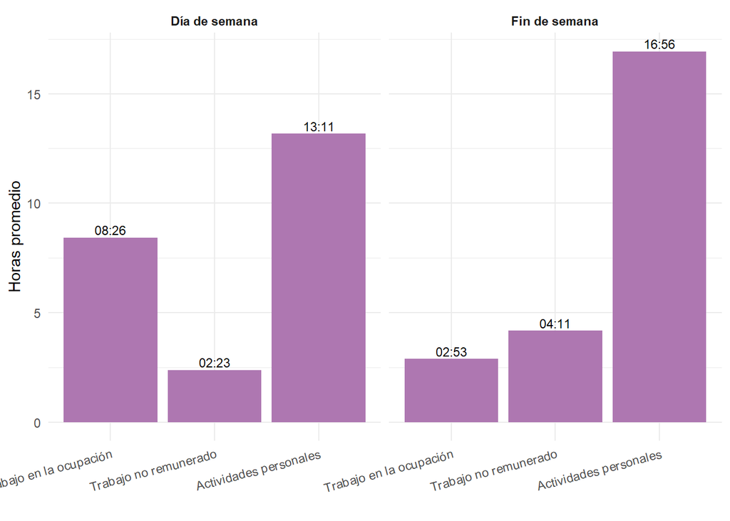

```r
ggplot(grafico1_N,
       aes(
         x = `Tiempo social`,
         y = as.numeric(
           substr(`Sector Público (redondeado)`, 1, 2)) +
         as.numeric(
           substr(`Sector Público (redondeado)`, 4, 5)) / 60
       )) +
  geom_col(fill = "#AE77B1") +
  geom_text(
    aes(label = `Sector Público (redondeado)`),
    vjust = -0.3,
    size = 3
  ) +
  facet_wrap(~ `Tipo de día`) +
  labs(
    x = "",
    y = "Horas promedio"
  ) +
  theme_minimal() +
  theme(
    axis.text.x = element_text(angle = 15, hjust = 1),
    strip.text = element_text(face = "bold")
  )
```

**2. Gráfico 24: Horas semanales promedio por género según tipo de actividad**

2.1. Elaboración del cuadro para el gráfico 24 adaptado a la estructura deseada

Este cuadro se desprende del cuadro 1.

```r
grafico2_N <- cuadro1 %>%
  # 1. Filtrar sector público
  filter(sector == "Sector público") %>%

  # 2. Mantener solo variables necesarias
  select(
    sexo,
    prom_t_sec1_dsem_h,
    prom_t_sec2_dsem_h,
    prom_t_sec3_dsem_h,
    prom_t_sec1_fsem_h,
    prom_t_sec2_fsem_h,
    prom_t_sec3_fsem_h
  ) %>%

  # 3. Pasar a formato largo
  pivot_longer(
    cols = -sexo,
    names_to  = "variable",
    values_to = "horas"
  ) %>%

  # 4. Identificar tipo de día, actividad y ponderar
  mutate(
    tipo_dia = if_else(
      str_detect(variable, "dsem"),
      "Día de semana",
      "Fin de semana"
    ),
    tiempo_social = case_when(
      str_detect(variable, "sec1") ~ "Trabajo en la ocupación",
      str_detect(variable, "sec2") ~ "Trabajo no remunerado",
      str_detect(variable, "sec3") ~ "Actividades personales"
    ),
    peso  = if_else(tipo_dia == "Día de semana", 5, 2),
    horas = horas * peso
  ) %>%

  # 5. Sumar semana + fin de semana
  group_by(sexo, tiempo_social) %>%
  summarise(
    horas = round(sum(horas)),
    .groups = "drop"
  )

head(grafico2_N)
```

| sexo | tiempo_social | horas |
| --- | --- | --- |
| Hombre | Actividades personales | 104 |
| Hombre | Trabajo en la ocupación | 51 |
| Hombre | Trabajo no remunerado | 13 |
| Mujer | Actividades personales | 96 |
| Mujer | Trabajo en la ocupación | 45 |
| Mujer | Trabajo no remunerado | 27 |

2.2. Gráfico N° 24: Horas semanales promedio por género según tipo de actividad

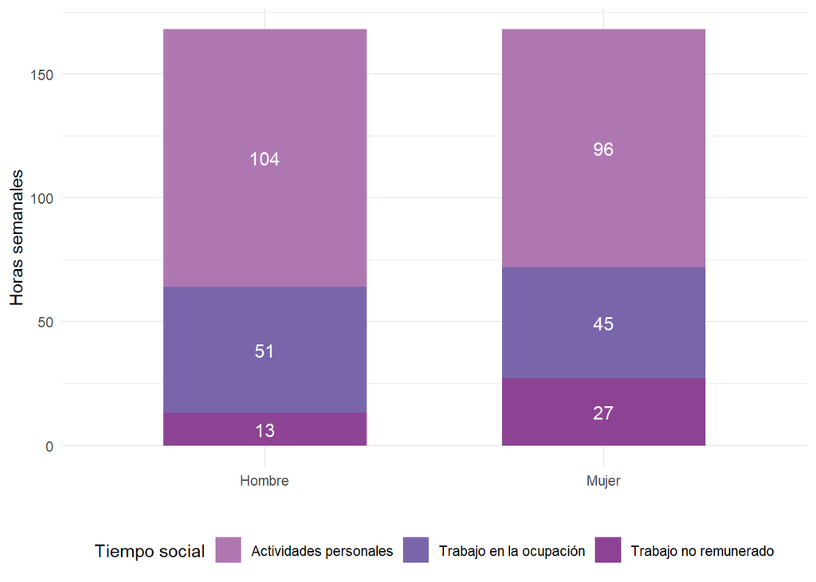

```r
ggplot(
  grafico2_N,
  aes(x = sexo, y = horas, fill = tiempo_social)
) +
  geom_col(width = 0.6) +
  geom_text(
    aes(label = horas),
    position = position_stack(vjust = 0.5),
    color = "white",
    size = 4
  ) +
  scale_fill_manual(
    values = c(
      "Trabajo en la ocupación"   = "#7865AA",
      "Trabajo no remunerado"     = "#8D4393",
      "Actividades personales"    = "#AE77B1"
    )
  ) +
  labs(
    x = "",
    y = "Horas semanales",
    fill = "Tiempo social"
  ) +
  theme_minimal() +
  theme(
    plot.title = element_text(face = "bold"),
    legend.position = "bottom"
  )
```

**3. Gráfico 25: Distribución porcentual de las horas semanales1 destinadas al trabajo remunerado y no remunerado, para cada género**

3.1. Elaboración del cuadro para el gráfico adaptado a la estructura deseada

Este cuadro se desprende del cuadro 1

```r
grafico3_N <- cuadro1 %>%
  # 1. Sector público
  filter(sector == "Sector público") %>%

  # 2. Solo día de semana
  select(
    sexo,
    prom_t_sec1_dsem_h,  # ocupación
    prom_t_sec2_dsem_h   # no remunerado
  ) %>%

  # 3. Largo
  pivot_longer(
    cols = -sexo,
    names_to  = "variable",
    values_to = "horas_diarias"
  ) %>%

  # 4. Identificar actividad y ponderar (×5 días)
  mutate(
    tiempo_social = case_when(
      str_detect(variable, "sec1") ~ "Trabajo en la ocupación",
      str_detect(variable, "sec2") ~ "Trabajo no remunerado"
    ),
    horas = horas_diarias * 5
  ) %>%

  # 5. Sumar por sexo y actividad
  group_by(sexo, tiempo_social) %>%
  summarise(
    horas = round(sum(horas)),
    .groups = "drop"
  ) %>%

  # 6. Calcular porcentajes dentro de cada sexo
  group_by(sexo) %>%
  mutate(
    porcentaje = horas / sum(horas) * 100,
    porcentaje_lab = paste0(round(porcentaje), "%")
  ) %>%
  ungroup()

head(grafico3_N)
```

| sexo | tiempo_social | horas | porcentaje | porcentaje_lab |
| --- | --- | --- | --- | --- |
| Hombre | Trabajo en la ocupación | 44 | 86.27451 | 86% |
| Hombre | Trabajo no remunerado | 7 | 13.72549 | 14% |
| Mujer | Trabajo en la ocupación | 40 | 71.42857 | 71% |
| Mujer | Trabajo no remunerado | 16 | 28.57143 | 29% |

3.2. Gráfico N° 25: Distribución porcentual de las horas semanales1 destinadas al trabajo remunerado y no remunerado, para cada género

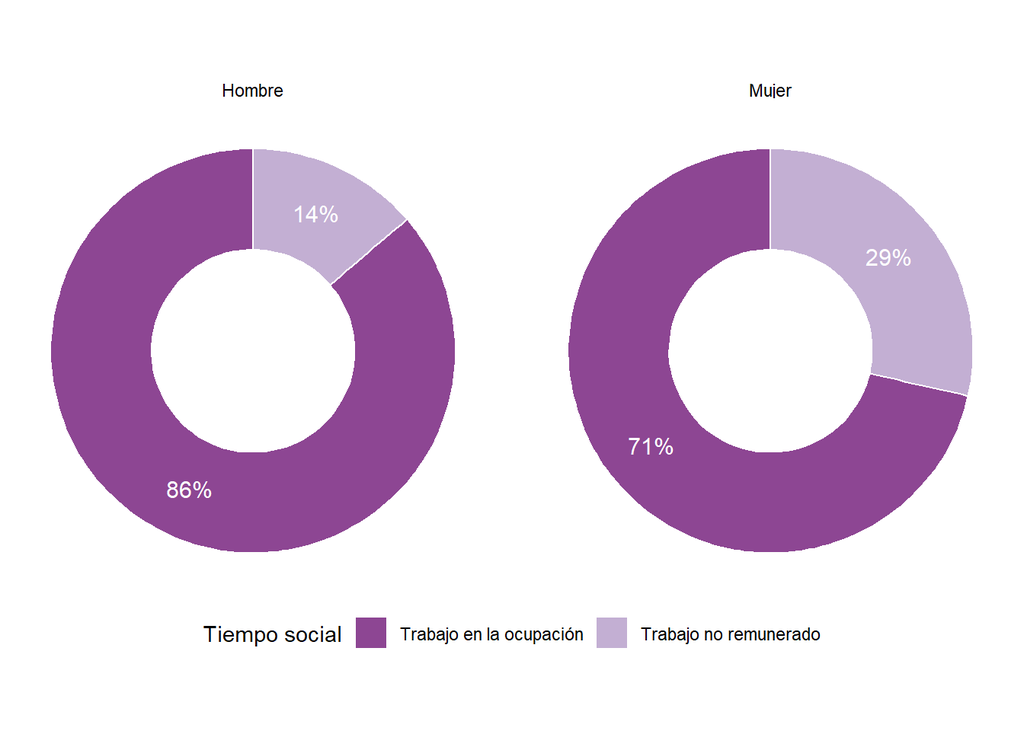

```r
ggplot(
  grafico3_N,
  aes(x = 2, y = porcentaje, fill = tiempo_social)
) +
  geom_col(width = 1, color = "white") +
  coord_polar(theta = "y") +
  xlim(0.5, 2.5) +                 # hueco central (anillo)
  facet_wrap(~ sexo) +
  geom_text(
    aes(label = porcentaje_lab),
    position = position_stack(vjust = 0.5),
    color = "white",
    size = 4
  ) +
  scale_fill_manual(
    values = c(
      "Trabajo en la ocupación" = "#8D4693",
      "Trabajo no remunerado"   = "#C3AFD3"
    )
  ) +
  labs(
    fill = "Tiempo social"
  ) +
  theme_void() +
  theme(
    plot.title = element_text(face = "bold", hjust = 0.5),
    legend.position = "bottom"
  )
```

**4. Gráfico 26: Distribución de horas semanales1 destinadas al trabajo remunerado y no remunerado, según rango de edad y género**

4.1. Elaboración del Cuadro 2 base para el gráfico

```r
cuadro2 <- base_personas %>%
  filter(sector == "Sector público") %>%
  mutate(
    across(
      all_of(vars_tiempo),
      ~ .x * factorfinal,
      .names = "w_{.col}"
    )
  ) %>%
  group_by(rango_edad, sexo) %>%
  summarise(
    n = sum(per_resfin, na.rm = TRUE),
    N = sum(factorfinal, na.rm = TRUE),
    across(starts_with("w_"), sum, na.rm = TRUE),
    .groups = "drop"
  ) %>%
  mutate(
    across(
      starts_with("w_"),
      ~ .x / N,
      .names = "prom_{sub('^w_', '', .col)}"
    )
  ) %>%
  select(-starts_with("w_"))

head(cuadro2)
```

| rango_edad | sexo | n | N | prom_t_sec1_dsem_h | prom_t_sec2_dsem_h | prom_t_sec3_dsem_h | prom_t_sec1_fsem_h | prom_t_sec2_fsem_h | prom_t_sec3_fsem_h |
| --- | --- | --- | --- | --- | --- | --- | --- | --- | --- |
| 18 a 29 años | Hombre | 45 | 90624.33 | 8.064486 | 0.8889425 | 15.04657 | 3.152495 | 2.121471 | 18.72603 |
| 18 a 29 años | Mujer | 54 | 98275.19 | 7.908393 | 3.0331050 | 13.05850 | 2.392001 | 4.901568 | 16.70643 |
| 30 a 39 años | Hombre | 73 | 133758.06 | 8.847318 | 1.5618284 | 13.59085 | 3.287522 | 3.453309 | 17.25917 |
| 30 a 39 años | Mujer | 118 | 226391.62 | 7.776642 | 3.9701083 | 12.25325 | 2.739772 | 5.210625 | 16.04960 |
| 40 a 49 años | Hombre | 110 | 196074.10 | 9.229502 | 1.6509775 | 13.11952 | 3.285105 | 3.565532 | 17.14936 |
| 40 a 49 años | Mujer | 105 | 181324.95 | 7.493956 | 3.5892780 | 12.91677 | 2.286116 | 5.610989 | 16.10290 |

4.2. Elaboración del cuadro para el gráfico adaptado a la estructura deseada

```r
grafico4_N<- cuadro2 %>%
  # 1. Seleccionar variables necesarias
  select(
    sexo,
    rango_edad,
    prom_t_sec1_dsem_h,
    prom_t_sec2_dsem_h,
    prom_t_sec1_fsem_h,
    prom_t_sec2_fsem_h
  ) %>%

  # 2. Pasar a formato largo
  pivot_longer(
    cols = -c(sexo, rango_edad),
    names_to  = "variable",
    values_to = "horas_diarias"
  ) %>%

  # 3. Identificar actividad y tipo de día
  mutate(
    tiempo_social = case_when(
      grepl("sec1", variable) ~ "Trabajo en la ocupación",
      grepl("sec2", variable) ~ "Trabajo no remunerado"
    ),
    tipo_dia = if_else(grepl("dsem", variable),
                       "Día de semana",
                       "Fin de semana"),
    peso = if_else(tipo_dia == "Día de semana", 5, 2),
    horas = horas_diarias * peso
  ) %>%

  # 4. Sumar horas semanales
  group_by(rango_edad, sexo, tiempo_social) %>%
  summarise(
    horas = round(sum(horas)),
    .groups = "drop"
  )

grafico4_N <- grafico4_N %>%
  # Total por edad y sexo (para porcentajes)
  group_by(rango_edad, sexo) %>%
  mutate(
    total_horas = sum(horas),
    porcentaje  = round(horas / total_horas * 100)
  ) %>%
  ungroup() %>%

  # Pasar a minutos
  mutate(
    minutos_num = horas * 60
  ) %>%

  # Espejo:
  # no remunerado izquierda / ocupación derecha
  mutate(
  minutos_plot = if_else(
    tiempo_social == "Trabajo en la ocupación",
    -minutos_num,
    minutos_num
   )
  ) %>%

  # Etiqueta: "XX%, XX"
  mutate(
    label = paste0(porcentaje, "%, ", horas)
  ) %>%

  # Eje Y combinado
  mutate(
    y_label = paste(rango_edad, sexo, sep = " – ")
  )

grafico4_N <- grafico4_N %>%
  mutate(
    y_label = factor(
      y_label,
      levels = rev(c(
        "18 a 29 años – Hombre",
        "18 a 29 años – Mujer",
        "30 a 39 años – Hombre",
        "30 a 39 años – Mujer",
        "40 a 49 años – Hombre",
        "40 a 49 años – Mujer",
        "50 a 59 años – Hombre",
        "50 a 59 años – Mujer",
        "60 años a más – Hombre",
        "60 años a más – Mujer"
      ))
    )
  )

head(grafico4_N)
```

| rango_edad | sexo | tiempo_social | horas | total_horas | porcentaje | minutos_num | minutos_plot | label | y_label |
| --- | --- | --- | --- | --- | --- | --- | --- | --- | --- |
| 18 a 29 años | Hombre | Trabajo en la ocupación | 47 | 56 | 84 | 2820 | -2820 | 84%, 47 | 18 a 29 años – Hombre |
| 18 a 29 años | Hombre | Trabajo no remunerado | 9 | 56 | 16 | 540 | 540 | 16%, 9 | 18 a 29 años – Hombre |
| 18 a 29 años | Mujer | Trabajo en la ocupación | 44 | 69 | 64 | 2640 | -2640 | 64%, 44 | 18 a 29 años – Mujer |
| 18 a 29 años | Mujer | Trabajo no remunerado | 25 | 69 | 36 | 1500 | 1500 | 36%, 25 | 18 a 29 años – Mujer |
| 30 a 39 años | Hombre | Trabajo en la ocupación | 51 | 66 | 77 | 3060 | -3060 | 77%, 51 | 30 a 39 años – Hombre |
| 30 a 39 años | Hombre | Trabajo no remunerado | 15 | 66 | 23 | 900 | 900 | 23%, 15 | 30 a 39 años – Hombre |

4.3. Gráfico N° 26: Distribución de horas semanales destinadas al trabajo remunerado y no remunerado, según rango de edad y género

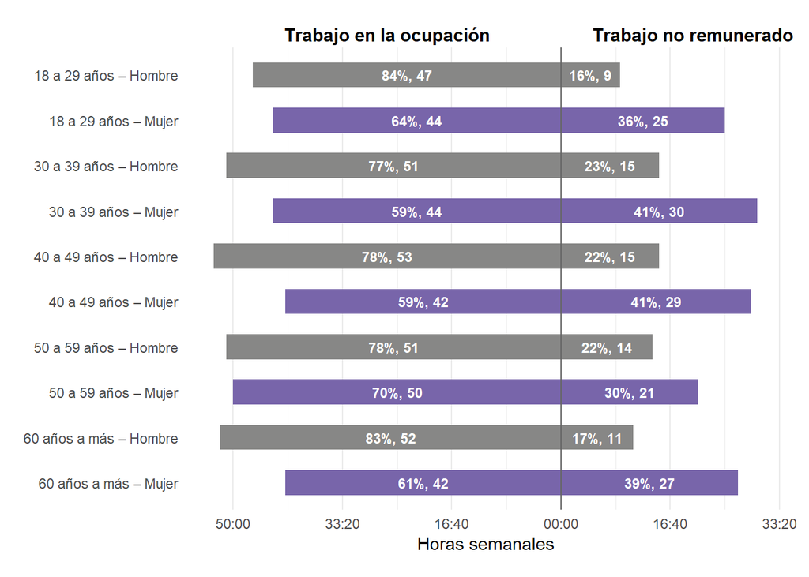

```r
ggplot(
  grafico4_N,
  aes(
    x = minutos_plot,
    y = y_label,
    fill = sexo
  )
) +
  geom_col(width = 0.55) +
  geom_text(
    aes(label = label),
    color = "white",
    size = 3.2,
    fontface = "bold",
    position = position_stack(vjust = 0.5)
  ) +
  geom_vline(xintercept = 0, color = "grey40") +
  scale_fill_manual(
    values = c(
      "Hombre" = "#878786",
      "Mujer"  = "#7865AA"
    ),
    guide = "none"
  ) +
  annotate(
    "text",
    x = -max(abs(grafico4_N$minutos_plot)) * 0.5,
    y = Inf,
    label = "Trabajo en la ocupación",
    vjust = -0.5,
    fontface = "bold",
    size = 4
  ) +
  annotate(
    "text",
    x =  max(abs(grafico4_N$minutos_plot)) * 0.38,
    y = Inf,
    label = "Trabajo no remunerado",
    vjust = -0.5,
    fontface = "bold",
    size = 4
  ) +
  scale_x_continuous(
    labels = function(x)
      sprintf(
        "%02d:%02d",
        abs(x) %/% 60,
        abs(x) %% 60
      )
  ) +
  labs(
    x = "Horas semanales",
    y = NULL
  ) +
  coord_cartesian(clip = "off") +
  theme_minimal() +
  theme(
    panel.grid.major.y = element_blank(),
    plot.margin = margin(t = 30, r = 15, b = 15, l = 15)
  )
```

**5. Gráfico 27: Distribución de horas semanales destinadas al trabajo remunerado y no remunerado, según nivel educativo y género**

5.1. Elaboración del Cuadro 3 base para el gráfico

```r
cuadro3 <- base_personas %>%

  # 1. Filtrar sector
  filter(sector == "Sector público") %>%

  # 2. Crear variables ponderadas
  mutate(
    w_t_sec1_dsem_h = t_sec1_dsem_h * factorfinal,
    w_t_sec2_dsem_h = t_sec2_dsem_h * factorfinal,
    w_t_sec3_dsem_h = t_sec3_dsem_h * factorfinal,
    w_t_sec1_fsem_h = t_sec1_fsem_h * factorfinal,
    w_t_sec2_fsem_h = t_sec2_fsem_h * factorfinal,
    w_t_sec3_fsem_h = t_sec3_fsem_h * factorfinal
  ) %>%

  # 3. Colapsar (agregar)
  group_by(niv_edu, sexo) %>%
  summarise(
    n = sum(per_resfin, na.rm = TRUE),
    N = sum(factorfinal, na.rm = TRUE),

    w_t_sec1_dsem_h = sum(w_t_sec1_dsem_h, na.rm = TRUE),
    w_t_sec2_dsem_h = sum(w_t_sec2_dsem_h, na.rm = TRUE),
    w_t_sec3_dsem_h = sum(w_t_sec3_dsem_h, na.rm = TRUE),
    w_t_sec1_fsem_h = sum(w_t_sec1_fsem_h, na.rm = TRUE),
    w_t_sec2_fsem_h = sum(w_t_sec2_fsem_h, na.rm = TRUE),
    w_t_sec3_fsem_h = sum(w_t_sec3_fsem_h, na.rm = TRUE)
  ) %>%

  # 4. Promedios ponderados
  mutate(
    prom_t_sec1_dsem_h = w_t_sec1_dsem_h / N,
    prom_t_sec2_dsem_h = w_t_sec2_dsem_h / N,
    prom_t_sec3_dsem_h = w_t_sec3_dsem_h / N,
    prom_t_sec1_fsem_h = w_t_sec1_fsem_h / N,
    prom_t_sec2_fsem_h = w_t_sec2_fsem_h / N,
    prom_t_sec3_fsem_h = w_t_sec3_fsem_h / N
  ) %>%

  # 5. Eliminar ponderaciones intermedias
  select(-starts_with("w_"))
head(cuadro3)
```

| niv_edu | sexo | n | N | prom_t_sec1_dsem_h | prom_t_sec2_dsem_h | prom_t_sec3_dsem_h | prom_t_sec1_fsem_h | prom_t_sec2_fsem_h | prom_t_sec3_fsem_h |
| --- | --- | --- | --- | --- | --- | --- | --- | --- | --- |
| Primaria y Ed. Básica | Hombre | 17 | 34510.99 | 9.566482 | 1.204004 | 13.22951 | 5.956472 | 2.289018 | 15.75451 |
| Primaria y Ed. Básica | Mujer | 9 | 17475.46 | 6.942004 | 5.021916 | 12.03608 | 3.968917 | 6.141111 | 13.88997 |
| Secundaria | Hombre | 85 | 165210.96 | 8.855086 | 1.509166 | 13.63575 | 4.715970 | 2.632556 | 16.65147 |
| Secundaria | Mujer | 50 | 86788.09 | 7.204755 | 4.213072 | 12.58217 | 3.598046 | 5.320390 | 15.08156 |
| Superior no universitaria | Hombre | 91 | 157895.13 | 8.865582 | 1.411558 | 13.72286 | 3.731856 | 3.141325 | 17.12682 |
| Superior no universitaria | Mujer | 137 | 247685.91 | 7.713179 | 3.454780 | 12.83204 | 2.620715 | 5.133172 | 16.24611 |

5.2. Elaboración del cuadro para el gráfico 5 adaptado a la estructura deseada

```r
grafico5_N<- cuadro3 %>%
  mutate(

    # horas semanales
    trabajo_ocupacion =
      prom_t_sec1_dsem_h * 5 +
      prom_t_sec1_fsem_h * 2,

    trabajo_no_remunerado =
      prom_t_sec2_dsem_h * 5 +
      prom_t_sec2_fsem_h * 2,

    actividades_personales =
      prom_t_sec3_dsem_h * 5 +
      prom_t_sec3_fsem_h * 2
  ) %>%

  select(
    niv_edu,
    sexo,
    trabajo_ocupacion,
    trabajo_no_remunerado,
    actividades_personales
  )

grafico5_N <- grafico5_N %>%

  pivot_longer(
    cols = c(trabajo_ocupacion, trabajo_no_remunerado),
    names_to = "tipo",
    values_to = "horas"
  ) %>%

  group_by(niv_edu, sexo) %>%

  mutate(

    total = sum(horas),

    porcentaje = round(horas / total * 100),

    minutos = round(horas * 60),

    minutos_plot = ifelse(
      tipo == "trabajo_ocupacion",
      -minutos,
      minutos
    ),

    label = paste0(
      porcentaje, "%; ",
      round(horas)
    ),

    y_label = paste(niv_edu, "–", sexo)
  ) %>%

  ungroup()

grafico5_N$niv_edu <- factor(
  grafico5_N$niv_edu,
  levels = rev(c(
    "Primaria y Ed. Básica",
    "Secundaria",
    "Superior no universitaria",
    "Universitaria y Postgrado"
  ))
)

grafico5_N$y_label <- factor(
  paste(grafico5_N$niv_edu, "–", grafico5_N$sexo),
  levels = rev(unique(paste(grafico5_N$niv_edu, "–", grafico5_N$sexo)))
)

head(grafico5_N)
```

| niv_edu | sexo | actividades_personales | tipo | horas | total | porcentaje | minutos | minutos_plot | label | y_label |
| --- | --- | --- | --- | --- | --- | --- | --- | --- | --- | --- |
| Primaria y Ed. Básica | Hombre | 97.65659 | trabajo_ocupacion | 59.74535 | 70.34341 | 85 | 3585 | -3585 | 85%; 60 | Primaria y Ed. Básica – Hombre |
| Primaria y Ed. Básica | Hombre | 97.65659 | trabajo_no_remunerado | 10.59806 | 70.34341 | 15 | 636 | 636 | 15%; 11 | Primaria y Ed. Básica – Hombre |
| Primaria y Ed. Básica | Mujer | 87.96035 | trabajo_ocupacion | 42.64785 | 80.03965 | 53 | 2559 | -2559 | 53%; 43 | Primaria y Ed. Básica – Mujer |
| Primaria y Ed. Básica | Mujer | 87.96035 | trabajo_no_remunerado | 37.39180 | 80.03965 | 47 | 2244 | 2244 | 47%; 37 | Primaria y Ed. Básica – Mujer |
| Secundaria | Hombre | 101.48169 | trabajo_ocupacion | 53.70737 | 66.51831 | 81 | 3222 | -3222 | 81%; 54 | Secundaria – Hombre |
| Secundaria | Hombre | 101.48169 | trabajo_no_remunerado | 12.81094 | 66.51831 | 19 | 769 | 769 | 19%; 13 | Secundaria – Hombre |

5.3. Gráfico N° 27: Distribución de horas semanales1 destinadas al trabajo remunerado y no remunerado, según nivel educativo y género

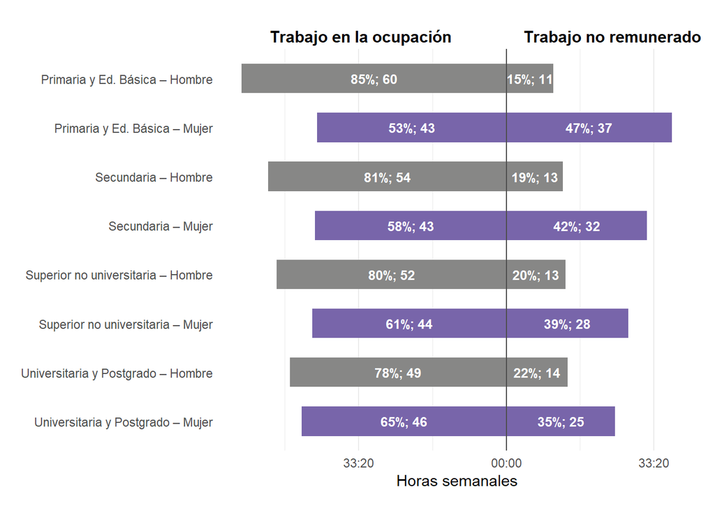

```r
ggplot(
  grafico5_N,
  aes(
    x = minutos_plot,
    y = y_label,
    fill = sexo
  )
) +

  geom_col(width = 0.6) +

  geom_text(
    aes(label = label),
    color = "white",
    size = 3.3,
    fontface = "bold",
    position = position_stack(vjust = 0.5)
  ) +

  geom_vline(xintercept = 0, color = "grey30") +

  scale_fill_manual(
    values = c(
      "Hombre" = "#878786",
      "Mujer"  = "#7865AA"
    ),
    guide = "none"
  ) +

  annotate(
    "text",
    x = -max(abs(grafico5_N$minutos_plot)) * 0.55,
    y = Inf,
    label = "Trabajo en la ocupación",
    fontface = "bold",
    size = 4,
    vjust = -0.6
  ) +

  annotate(
    "text",
    x = max(abs(grafico5_N$minutos_plot)) * 0.40,
    y = Inf,
    label = "Trabajo no remunerado",
    fontface = "bold",
    size = 4,
    vjust = -0.6
  ) +

  scale_x_continuous(
    labels = function(x)
      sprintf(
        "%02d:%02d",
        abs(x) %/% 60,
        abs(x) %% 60
      )
  ) +

  labs(
    x = "Horas semanales",
    y = NULL
  ) +

  coord_cartesian(clip = "off") +

  theme_minimal() +

  theme(
    panel.grid.major.y = element_blank(),
    plot.margin = margin(t = 35, r = 15, b = 15, l = 15)
  )
```

**6. Gráfico 28: Distribución de horas semanales1 destinadas al trabajo remunerado y no remunerado, según tenencia de pareja y género**

6.1. Elaboración del Cuadro 4 base para el gráfico

```r
cuadro4 <- base_personas %>%

  # 1. Filtrar sector
  filter(sector == "Sector público") %>%

  # 2. Crear variables ponderadas
  mutate(
    w_t_sec1_dsem_h = t_sec1_dsem_h * factorfinal,
    w_t_sec2_dsem_h = t_sec2_dsem_h * factorfinal,
    w_t_sec3_dsem_h = t_sec3_dsem_h * factorfinal,
    w_t_sec1_fsem_h = t_sec1_fsem_h * factorfinal,
    w_t_sec2_fsem_h = t_sec2_fsem_h * factorfinal,
    w_t_sec3_fsem_h = t_sec3_fsem_h * factorfinal
  ) %>%

  # 3. Colapsar datos
  group_by(ecivil, sexo) %>%
  summarise(

    n = sum(per_resfin, na.rm = TRUE),
    N = sum(factorfinal, na.rm = TRUE),

    w_t_sec1_dsem_h = sum(w_t_sec1_dsem_h, na.rm = TRUE),
    w_t_sec2_dsem_h = sum(w_t_sec2_dsem_h, na.rm = TRUE),
    w_t_sec3_dsem_h = sum(w_t_sec3_dsem_h, na.rm = TRUE),

    w_t_sec1_fsem_h = sum(w_t_sec1_fsem_h, na.rm = TRUE),
    w_t_sec2_fsem_h = sum(w_t_sec2_fsem_h, na.rm = TRUE),
    w_t_sec3_fsem_h = sum(w_t_sec3_fsem_h, na.rm = TRUE)
  ) %>%

  # 4. Promedios ponderados
  mutate(

    prom_t_sec1_dsem_h = w_t_sec1_dsem_h / N,
    prom_t_sec2_dsem_h = w_t_sec2_dsem_h / N,
    prom_t_sec3_dsem_h = w_t_sec3_dsem_h / N,

    prom_t_sec1_fsem_h = w_t_sec1_fsem_h / N,
    prom_t_sec2_fsem_h = w_t_sec2_fsem_h / N,
    prom_t_sec3_fsem_h = w_t_sec3_fsem_h / N
  ) %>%

  # 5. Eliminar ponderaciones
  select(-starts_with("w_"))
head(cuadro4)
```

| ecivil | sexo | n | N | prom_t_sec1_dsem_h | prom_t_sec2_dsem_h | prom_t_sec3_dsem_h | prom_t_sec1_fsem_h | prom_t_sec2_fsem_h | prom_t_sec3_fsem_h |
| --- | --- | --- | --- | --- | --- | --- | --- | --- | --- |
| Con pareja | Hombre | 266 | 493506.2 | 8.779737 | 1.570113 | 13.65015 | 3.490941 | 3.205095 | 17.30396 |
| Con pareja | Mujer | 222 | 413992.2 | 7.749762 | 3.625556 | 12.62468 | 2.489881 | 5.634631 | 15.87549 |
| Sin pareja | Hombre | 110 | 220371.0 | 9.125541 | 1.095295 | 13.77916 | 3.071537 | 2.877681 | 18.05078 |
| Sin pareja | Mujer | 201 | 380855.2 | 8.337533 | 2.824620 | 12.83785 | 2.391700 | 4.657058 | 16.95124 |

6.2. Elaboración del cuadro para el gráfico adaptado a la estructura deseada

```r
grafico6_N <- cuadro4 %>%

  mutate(

    # Horas semanales
    trabajo_ocupacion =
      (prom_t_sec1_dsem_h * 5) +
      (prom_t_sec1_fsem_h * 2),

    trabajo_no_remunerado =
      (prom_t_sec2_dsem_h * 5) +
      (prom_t_sec2_fsem_h * 2),

    actividades_personales =
      (prom_t_sec3_dsem_h * 5) +
      (prom_t_sec3_fsem_h * 2)

  ) %>%

  select(
    ecivil,
    sexo,
    trabajo_ocupacion,
    trabajo_no_remunerado,
    actividades_personales
  ) %>%

  mutate(

    # redondear horas
    trabajo_ocupacion = round(trabajo_ocupacion),
    trabajo_no_remunerado = round(trabajo_no_remunerado),
    actividades_personales = round(actividades_personales)

  )

grafico6_N <- grafico6_N %>%

  pivot_longer(
    cols = c(trabajo_ocupacion, trabajo_no_remunerado),
    names_to = "tipo",
    values_to = "horas"
  ) %>%

  group_by(ecivil, sexo) %>%

  mutate(

    total = sum(horas),
    porcentaje = round(horas / total * 100),

    minutos = horas * 60,

    minutos_plot = ifelse(
      tipo == "trabajo_ocupacion",
      -minutos,
      minutos
    ),

    label = paste0(
      porcentaje, "%; ",
      round(horas)
    )

  ) %>%

  ungroup()

grafico6_N$ecivil <- factor(
  grafico6_N$ecivil,
  levels = c("Sin pareja", "Con pareja")
)

grafico6_N$y_label <- factor(
  paste(grafico6_N$ecivil, "–", grafico6_N$sexo),
  levels = rev(unique(paste(grafico6_N$ecivil, "–", grafico6_N$sexo)))
)

head(grafico6_N)
```

| ecivil | sexo | actividades_personales | tipo | horas | total | porcentaje | minutos | minutos_plot | label | y_label |
| --- | --- | --- | --- | --- | --- | --- | --- | --- | --- | --- |
| Con pareja | Hombre | 103 | trabajo_ocupacion | 51 | 65 | 78 | 3060 | -3060 | 78%; 51 | Con pareja – Hombre |
| Con pareja | Hombre | 103 | trabajo_no_remunerado | 14 | 65 | 22 | 840 | 840 | 22%; 14 | Con pareja – Hombre |
| Con pareja | Mujer | 95 | trabajo_ocupacion | 44 | 73 | 60 | 2640 | -2640 | 60%; 44 | Con pareja – Mujer |
| Con pareja | Mujer | 95 | trabajo_no_remunerado | 29 | 73 | 40 | 1740 | 1740 | 40%; 29 | Con pareja – Mujer |
| Sin pareja | Hombre | 105 | trabajo_ocupacion | 52 | 63 | 83 | 3120 | -3120 | 83%; 52 | Sin pareja – Hombre |
| Sin pareja | Hombre | 105 | trabajo_no_remunerado | 11 | 63 | 17 | 660 | 660 | 17%; 11 | Sin pareja – Hombre |

6.3. Gráfico N° 28: Distribución de horas semanales destinadas al trabajo remunerado y no remunerado, según tenencia de pareja y género

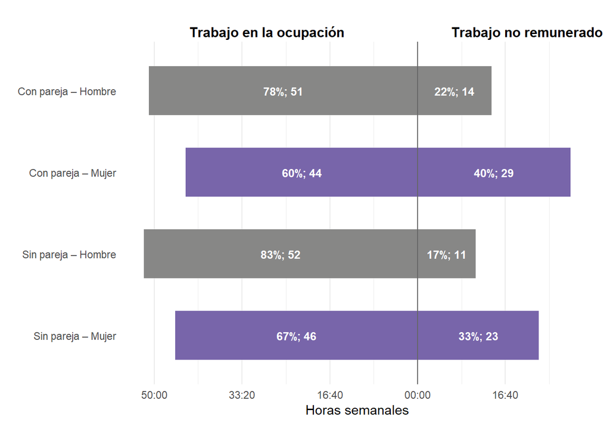

```r
ggplot(
  grafico6_N,
  aes(
    x = minutos_plot,
    y = y_label,
    fill = sexo
  )
) +

  geom_col(width = 0.6) +

  geom_text(
    aes(label = label),
    color = "white",
    size = 3.3,
    fontface = "bold",
    position = position_stack(vjust = 0.5)
  ) +

  geom_vline(xintercept = 0, color = "grey40") +

  scale_fill_manual(
    values = c(
      "Hombre" = "#878786",
      "Mujer"  = "#7865AA"
    ),
    guide = "none"
  ) +

  annotate(
    "text",
    x = -max(abs(grafico6_N$minutos_plot)) * 0.55,
    y = Inf,
    label = "Trabajo en la ocupación",
    fontface = "bold",
    size = 4,
    vjust = -0.5
  ) +

  annotate(
    "text",
    x = max(abs(grafico6_N$minutos_plot)) * 0.40,
    y = Inf,
    label = "Trabajo no remunerado",
    fontface = "bold",
    size = 4,
    vjust = -0.5
  ) +

  scale_x_continuous(
    labels = function(x)
      sprintf(
        "%02d:%02d",
        abs(x) %/% 60,
        abs(x) %% 60
      )
  ) +

  labs(
    x = "Horas semanales",
    y = NULL
  ) +

  coord_cartesian(clip = "off") +

  theme_minimal() +

  theme(
    panel.grid.major.y = element_blank(),
    plot.margin = margin(t = 35, r = 15, b = 15, l = 15)
  )
```

**Gráfico 29: Distribución de horas semanales destinadas al trabajo remunerado y no remunerado, según grupo ocupacional y género**

7.1. Elaboración del Cuadro 5 base para el gráfico

```r
cuadro5 <- base_personas %>%
  filter(sector == "Sector público") %>%
  mutate(
    across(
      all_of(vars_tiempo),
      ~ .x * factorfinal,
      .names = "w_{.col}"
    )
  ) %>%
  group_by(gr_grupo_ocu, sexo) %>%
  summarise(
    n = sum(per_resfin, na.rm = TRUE),
    N = sum(factorfinal, na.rm = TRUE),
    across(starts_with("w_"), sum, na.rm = TRUE),
    .groups = "drop"
  ) %>%
  mutate(
    across(
      starts_with("w_"),
      ~ .x / N,
      .names = "prom_{sub('^w_', '', .col)}"
    )
  ) %>%
  select(-starts_with("w_"))

head(cuadro5)
```

| gr_grupo_ocu | sexo | n | N | prom_t_sec1_dsem_h | prom_t_sec2_dsem_h | prom_t_sec3_dsem_h | prom_t_sec1_fsem_h | prom_t_sec2_fsem_h | prom_t_sec3_fsem_h |
| --- | --- | --- | --- | --- | --- | --- | --- | --- | --- |
| Funcionarios y directivos | Hombre | 12 | 20046.16 | 9.316865 | 0.7165275 | 13.96661 | 2.214678 | 2.881755 | 18.90357 |
| Funcionarios y directivos | Mujer | 15 | 29099.86 | 8.284930 | 1.9984636 | 13.71661 | 1.997373 | 5.390845 | 16.61178 |
| Profesionales | Hombre | 61 | 114138.46 | 9.526574 | 1.2879113 | 13.18552 | 1.865546 | 3.519666 | 18.61479 |
| Profesionales | Mujer | 52 | 96058.73 | 9.049442 | 2.4444532 | 12.50610 | 1.131104 | 5.439657 | 17.42924 |
| Técnicos | Hombre | 40 | 77270.30 | 9.185632 | 1.4037914 | 13.41058 | 1.858846 | 3.717672 | 18.42348 |
| Técnicos | Mujer | 36 | 74027.60 | 9.054814 | 2.5425505 | 12.40264 | 2.369806 | 4.867275 | 16.76292 |

7.2. Elaboración del cuadro para el gráfico adaptado a la estructura deseada

```r
grafico7_N <- cuadro5 %>%   # reemplaza "base" por el nombre de tu dataframe
  mutate(

    trabajo_ocupacion = (prom_t_sec1_dsem_h * 5 + prom_t_sec1_fsem_h * 2),

    trabajo_no_remunerado = (prom_t_sec2_dsem_h * 5 + prom_t_sec2_fsem_h * 2),

    actividades_personales = (prom_t_sec3_dsem_h * 5 + prom_t_sec3_fsem_h * 2)

  ) %>%

  select(
    gr_grupo_ocu,
    sexo,
    trabajo_ocupacion,
    trabajo_no_remunerado,
    actividades_personales
  ) %>%

  mutate(
    sexo = factor(sexo, levels = c("Hombre","Mujer")),

    gr_grupo_ocu = factor(
      gr_grupo_ocu,
      levels = c(
        "Funcionarios y directivos",
        "Profesionales",
        "Técnicos",
        "Auxiliares",
        "Prestadores de servicios directos",
        "Prestadores de servicios indirectos",
        "Carreras especiales"
      )
    )
  ) %>%

  arrange(gr_grupo_ocu, sexo)

grafico7_N <- grafico7_N %>%

  mutate(
    ocup_min = trabajo_ocupacion * 60,
    no_rem_min = trabajo_no_remunerado * 60
  ) %>%

  pivot_longer(
    cols = c(ocup_min, no_rem_min),
    names_to = "tipo",
    values_to = "minutos"
  ) %>%

  group_by(gr_grupo_ocu, sexo) %>%

  mutate(

    total = sum(minutos),

    porcentaje = round(minutos / total * 100),

    horas = round(minutos / 60),

    minutos_plot = ifelse(tipo == "ocup_min", -minutos, minutos),

    label = paste0(
      porcentaje,
      "%; ",
      horas
    ),

    y_label = paste(gr_grupo_ocu, sexo, sep = " – ")

  ) %>%

  ungroup() %>%

  mutate(
    y_label = factor(
      y_label,
      levels = rev(c(
        "Funcionarios y directivos – Hombre",
        "Funcionarios y directivos – Mujer",
        "Profesionales – Hombre",
        "Profesionales – Mujer",
        "Técnicos – Hombre",
        "Técnicos – Mujer",
        "Auxiliares – Hombre",
        "Auxiliares – Mujer",
        "Prestadores de servicios directos – Hombre",
        "Prestadores de servicios directos – Mujer",
        "Prestadores de servicios indirectos – Hombre",
        "Prestadores de servicios indirectos – Mujer",
        "Carreras especiales – Hombre",
        "Carreras especiales – Mujer"
      ))
    )
  )

head(grafico7_N)
```

| gr_grupo_ocu | sexo | trabajo_ocupacion | trabajo_no_remunerado | actividades_personales | tipo | minutos | total | porcentaje | horas | minutos_plot | label | y_label |
| --- | --- | --- | --- | --- | --- | --- | --- | --- | --- | --- | --- | --- |
| Funcionarios y directivos | Hombre | 51.01368 | 9.346147 | 107.6402 | ocup_min | 3060.8208 | 3621.590 | 85 | 51 | -3060.8208 | 85%; 51 | Funcionarios y directivos – Hombre |
| Funcionarios y directivos | Hombre | 51.01368 | 9.346147 | 107.6402 | no_rem_min | 560.7688 | 3621.590 | 15 | 9 | 560.7688 | 15%; 9 | Funcionarios y directivos – Hombre |
| Funcionarios y directivos | Mujer | 45.41939 | 20.774009 | 101.8066 | ocup_min | 2725.1636 | 3971.604 | 69 | 45 | -2725.1636 | 69%; 45 | Funcionarios y directivos – Mujer |
| Funcionarios y directivos | Mujer | 45.41939 | 20.774009 | 101.8066 | no_rem_min | 1246.4405 | 3971.604 | 31 | 21 | 1246.4405 | 31%; 21 | Funcionarios y directivos – Mujer |
| Profesionales | Hombre | 51.36396 | 13.478888 | 103.1572 | ocup_min | 3081.8376 | 3890.571 | 79 | 51 | -3081.8376 | 79%; 51 | Profesionales – Hombre |
| Profesionales | Hombre | 51.36396 | 13.478888 | 103.1572 | no_rem_min | 808.7333 | 3890.571 | 21 | 13 | 808.7333 | 21%; 13 | Profesionales – Hombre |

7.3. Gráfico N° 29: Distribución de horas semanales destinadas al trabajo remunerado y no remunerado, según grupo ocupacional y género

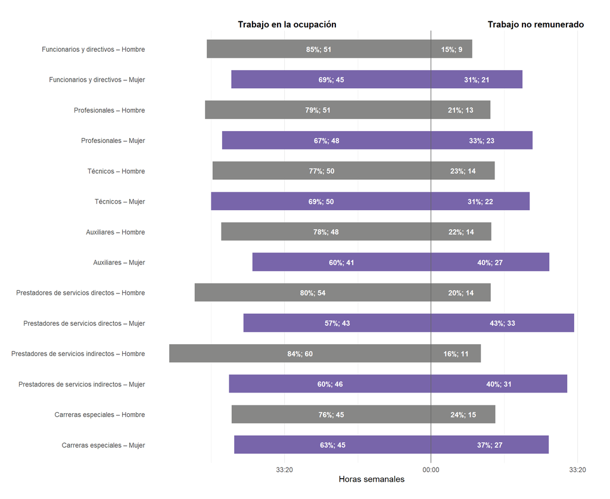

```r
ggplot(
  grafico7_N,
  aes(
    x = minutos_plot,
    y = y_label,
    fill = sexo
  )
) +

  geom_col(width = 0.6) +

  geom_text(
    aes(label = label),
    color = "white",
    size = 3.3,
    fontface = "bold",
    position = position_stack(vjust = 0.5)
  ) +

  geom_vline(xintercept = 0, color = "grey40") +

  scale_fill_manual(
    values = c(
      "Hombre" = "#878786",
      "Mujer"  = "#7865AA"
    ),
    guide = "none"
  ) +

  annotate(
    "text",
    x = -max(abs(grafico7_N$minutos_plot)) * 0.55,
    y = Inf,
    label = "Trabajo en la ocupación",
    fontface = "bold",
    size = 4,
    vjust = -0.5
  ) +

  annotate(
    "text",
    x = max(abs(grafico7_N$minutos_plot)) * 0.40,
    y = Inf,
    label = "Trabajo no remunerado",
    fontface = "bold",
    size = 4,
    vjust = -0.5
  ) +

  scale_x_continuous(
    labels = function(x)
      sprintf(
        "%02d:%02d",
        abs(x) %/% 60,
        abs(x) %% 60
      )
  ) +

  labs(
    x = "Horas semanales",
    y = NULL
  ) +

  coord_cartesian(clip = "off") +

  theme_minimal() +

  theme(
    panel.grid.major.y = element_blank(),
    plot.margin = margin(t = 40, r = 20, b = 20, l = 15)
  )
```

**8. Gráfico 30: Carga del trabajo no remunerado por género, según desglose de actividad**

8.1. Elaboración del Cuadro 6 base para el gráfico

```r
vars_tiempo_2 <- c(
  "t_sec2_dsem_h", "t_sec2_fsem_h",
  "t_g3_dsem_h", "t_g4_dsem_h", "t_g5_dsem_h",
  "t_g3_fsem_h", "t_g4_fsem_h", "t_g5_fsem_h"
)

cuadro6 <- base_personas %>%
  filter(sector == "Sector público") %>%
  mutate(
    across(
      all_of(vars_tiempo_2),
      ~ .x * factorfinal,
      .names = "w_{.col}"
    )
  ) %>%
  group_by(sexo) %>%
  summarise(
    n = sum(per_resfin, na.rm = TRUE),
    N = sum(factorfinal, na.rm = TRUE),
    across(starts_with("w_"), sum, na.rm = TRUE),
    .groups = "drop"
  ) %>%
  mutate(
    across(
      starts_with("w_"),
      ~ .x / N,
      .names = "prom_{sub('^w_', '', .col)}"
    )
  ) %>%
  select(-starts_with("w_"))

head(cuadro6)
```

| sexo | n | N | prom_t_sec2_dsem_h | prom_t_sec2_fsem_h | prom_t_g3_dsem_h | prom_t_g4_dsem_h | prom_t_g5_dsem_h | prom_t_g3_fsem_h | prom_t_g4_fsem_h | prom_t_g5_fsem_h |
| --- | --- | --- | --- | --- | --- | --- | --- | --- | --- | --- |
| Hombre | 376 | 713877.2 | 1.423539 | 3.104023 | 0.8725599 | 0.5071646 | 0.04381418 | 1.978167 | 0.9562149 | 0.1696415 |
| Mujer | 423 | 794847.5 | 3.241783 | 5.166222 | 2.0556426 | 1.1170656 | 0.06907498 | 3.645436 | 1.2996763 | 0.2211105 |

8.2. Elaboración del cuadro para el gráfico adaptado a la estructura deseada

```r
grafico8_N <- cuadro6 %>%

  mutate(

    # Trabajo no remunerado total
    trabajo_no_remunerado =
      (prom_t_sec2_dsem_h * 5) +
      (prom_t_sec2_fsem_h * 2),


    # Trabajo doméstico hogar (g3)
    domestico_hogar =
      (prom_t_g3_dsem_h * 5) +
      (prom_t_g3_fsem_h * 2),


    # Cuidado miembros hogar (g4)
    cuidado_hogar =
      (prom_t_g4_dsem_h * 5) +
      (prom_t_g4_fsem_h * 2),


    # Otros hogares / comunidad (g5)
    otros_hogares =
      (prom_t_g5_dsem_h * 5) +
      (prom_t_g5_fsem_h * 2)

  ) %>%

  select(
    sexo,
    trabajo_no_remunerado,
    domestico_hogar,
    cuidado_hogar,
    otros_hogares
  )

grafico8_N <- grafico8_N %>%
  mutate(
    trabajo_no_remunerado = round(trabajo_no_remunerado),
    domestico_hogar = round(domestico_hogar,1),
    cuidado_hogar = round(cuidado_hogar,1),
    otros_hogares = round(otros_hogares,2)
  )

temp_8_N <- grafico8_N %>%
  summarise(
    trabajo_no_remunerado = sum(trabajo_no_remunerado),
    domestico_hogar = sum(domestico_hogar),
    cuidado_hogar = sum(cuidado_hogar),
    otros_hogares = sum(otros_hogares)
  )

grafico8_N <- bind_rows(
  grafico8_N,
  temp_8_N
)

head(grafico8_N)
```

| sexo | trabajo_no_remunerado | domestico_hogar | cuidado_hogar | otros_hogares |
| --- | --- | --- | --- | --- |
| Hombre | 13 | 8.3 | 4.4 | 0.56 |
| Mujer | 27 | 17.6 | 8.2 | 0.79 |
| NA | 40 | 25.9 | 12.6 | 1.35 |

```r
barra_lateral <- grafico8_N %>%
  filter(sexo %in% c("Hombre","Mujer")) %>%

  mutate(
    horas = trabajo_no_remunerado
  ) %>%

  select(sexo, horas)
```

```r
base_graf <- grafico8_N %>%
  filter(sexo %in% c("Hombre","Mujer")) %>%

  pivot_longer(
    cols = c(domestico_hogar, cuidado_hogar, otros_hogares),
    names_to = "tipo",
    values_to = "valor"
  ) %>%

  mutate(
    tipo = recode(
      tipo,
      domestico_hogar = "Trabajo doméstico",
      cuidado_hogar   = "Cuidado de miembros del hogar",
      otros_hogares   = "Trabajo comunitario, voluntario"
    ),

    tipo = factor(
      tipo,
      levels = c(
        "Trabajo doméstico",
        "Cuidado de miembros del hogar",
        "Trabajo comunitario, voluntario"
      )
    )
  ) %>%

  group_by(tipo) %>%
  mutate(
    porcentaje = valor / sum(valor)
  ) %>%

  ungroup()
```

```r
graf_barra <- grafico8_N %>%

  filter(sexo %in% c("Hombre","Mujer")) %>%

  ggplot(aes(x = "", y = trabajo_no_remunerado, fill = sexo)) +

  geom_col(width = 0.6) +

  geom_text(
    aes(label = round(trabajo_no_remunerado)),
    position = position_stack(vjust = 0.5),
    color = "white",
    fontface = "bold",
    size = 5
  ) +

  scale_fill_manual(
    values = c(
      "Hombre" = "#878786",
      "Mujer"  = "#7865AA"
    )
  ) +

  labs(
    title = "Trab no remunerado\n(horas semanales)"
  ) +

  theme_void() +

  theme(
    legend.position = "none",
    plot.title = element_text(size = 10, hjust = 0.5)
  )
```

```r
graf_anillos <- ggplot(base_graf,
       aes(x = 2, y = porcentaje, fill = sexo)) +

  geom_col(width = 1, color = "white") +

  coord_polar(theta = "y") +

  xlim(1, 2.5) +

  geom_text(
    aes(label = paste0(round(porcentaje*100), "%")),
    position = position_stack(vjust = 0.5),
    color = "white",
    fontface = "bold",
    size = 4
  ) +

  facet_wrap(~tipo, nrow = 1) +

  scale_fill_manual(
    values = c(
      "Hombre" = "#878786",
      "Mujer" = "#7865AA"
    )
  ) +

  theme_void() +

  theme(
    legend.position = "none",
    strip.text = element_text(face = "bold")
  )
```

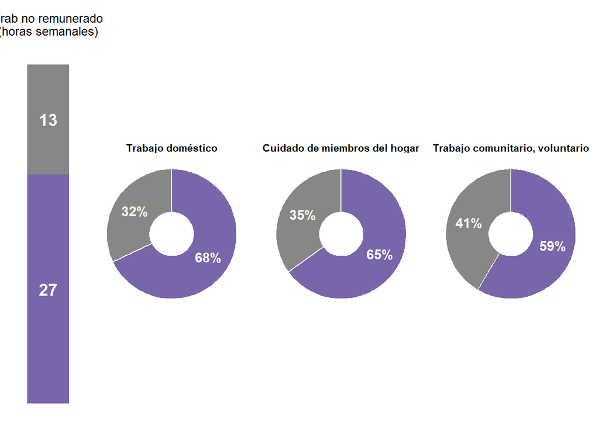

```r
(graf_barra | graf_anillos) +
  plot_layout(widths = c(0.5, 3))
```

**9. Gráfico 31: Carga de las labores de cuidado por género, según desglose de actividad**

9.1. Elaboración del Cuadro 7 base para el gráfico

```r
vars_tiempo_cuidado <- c(
  "t_g4_dsem_h","t_g4_fsem_h",
  "t_41_dsem_h","t_41_fsem_h",
  "t_42_dsem_h","t_42_fsem_h",
  "t_43_dsem_h","t_43_fsem_h",
  "t_44_dsem_h","t_44_fsem_h"
)

cuadro7 <- base_personas %>%

  filter(sector == "Sector público") %>%

  mutate(
    across(
      all_of(vars_tiempo_cuidado),
      \(x) x * factorfinal,
      .names = "w_{.col}"
    )
  ) %>%

  group_by(sexo) %>%

  summarise(

    n = sum(per_resfin, na.rm = TRUE),
    N = sum(factorfinal, na.rm = TRUE),

    across(starts_with("w_"), \(x) sum(x, na.rm = TRUE)),

    .groups = "drop"

  ) %>%

  mutate(

    across(
      starts_with("w_"),
      \(x) x / N,
      .names = "prom_{sub('^w_', '', .col)}"
    )

  ) %>%

  select(-starts_with("w_"))
```

9.2. Elaboración del cuadro para el gráfico adaptado a la estructura deseada

```r
grafico9_N <- cuadro7 %>%

  mutate(

    cuidado_total = round(
      prom_t_g4_dsem_h * 5 +
      prom_t_g4_fsem_h * 2,
    1
    ),

    cuidado_ninos =
      prom_t_41_dsem_h * 5 +
      prom_t_41_fsem_h * 2,

    cuidado_adultos =
      prom_t_43_dsem_h * 5 +
      prom_t_43_fsem_h * 2,

    otros =
      (prom_t_42_dsem_h * 5 + prom_t_42_fsem_h * 2) +
      (prom_t_44_dsem_h * 5 + prom_t_44_fsem_h * 2)

  ) %>%

  select(
    sexo,
    cuidado_total,
    cuidado_ninos,
    cuidado_adultos,
    otros
  )
```

```r
base_graf_cuidado <- grafico9_N %>%

  pivot_longer(
    cols = c(cuidado_ninos, cuidado_adultos, otros),
    names_to = "tipo",
    values_to = "horas"
  ) %>%

  mutate(

    tipo = recode(
      tipo,
      cuidado_ninos = "Cuidado de \n niños (0-14)",
      cuidado_adultos = "Cuidado de \n adultos mayores",
      otros = "Otros"
    ),

    tipo = factor(
      tipo,
      levels = c(
        "Cuidado de \n niños (0-14)",
        "Cuidado de \n adultos mayores",
        "Otros"
      )
    )
  ) %>%

  group_by(tipo) %>%

  mutate(
    porcentaje = horas / sum(horas)
  ) %>%

  ungroup()
```

```r
graf_barra_cuidado <- grafico9_N %>%

  ggplot(aes(x = "", y = cuidado_total, fill = sexo)) +

  geom_col(width = 0.7) +

  geom_text(
    aes(label = round(cuidado_total,1)),
    position = position_stack(vjust = 0.5),
    color = "white",
    fontface = "bold",
    size = 5
  ) +

  scale_fill_manual(
    values = c(
      "Hombre" = "#878786",
      "Mujer" = "#7865AA"
    )
  ) +

  labs(
    title = "Trab de cuidado \n(horas semanales)"
  ) +

  theme_void() +

  theme(
    legend.position = "bottom",
    plot.title = element_text(size = 11, hjust = 0.5)
  )
```

```r
graf_anillos_cuidado <- ggplot(
  base_graf_cuidado,
  aes(x = 2, y = porcentaje, fill = sexo)
) +

  geom_col(width = 1, color = "white") +

  coord_polar(theta = "y") +

  xlim(1, 2.5) +

  geom_text(
    aes(label = paste0(round(porcentaje*100), "%")),
    position = position_stack(vjust = 0.5),
    color = "white",
    fontface = "bold",
    size = 4
  ) +

  facet_wrap(~tipo, nrow = 1) +

  scale_fill_manual(
    values = c(
      "Hombre" = "#878786",
      "Mujer" = "#7865AA"
    )
  ) +

  theme_void() +

  theme(
    legend.position = "none",
    strip.text = element_text(face = "bold", size = 11)
  )
```

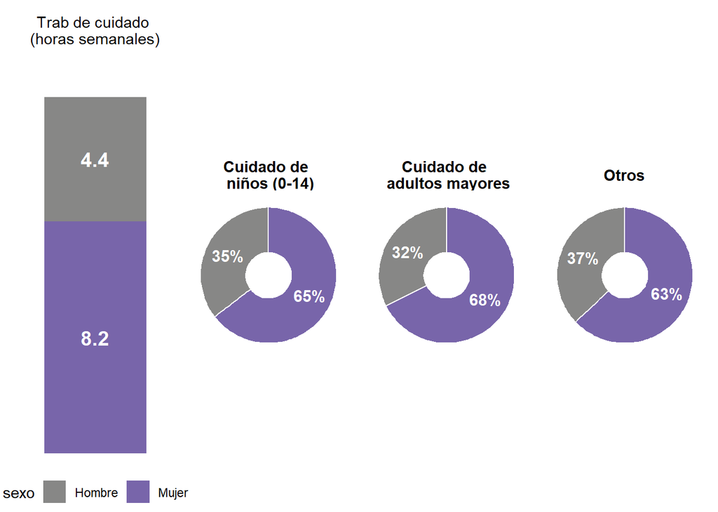

```r
(graf_barra_cuidado | graf_anillos_cuidado) +
  plot_layout(widths = c(1,3))
```

##FIN.